# planteamiento del proyecto

### Ethereum (ETH-USD)

```r
eth <- read.csv("datos_csv/ETH.csv")
pander::pander(head(eth,10))
```

| Date | Open | High | Low | Close | Adj.Close | Volume |
| --- | --- | --- | --- | --- | --- | --- |
| 2021-09-04 | 3938 | 3969 | 3838 | 3888 | 3888 | 2.081e+10 |
| 2021-09-05 | 3886 | 3979 | 3838 | 3952 | 3952 | 1.837e+10 |
| 2021-09-06 | 3952 | 3968 | 3869 | 3928 | 3928 | 1.867e+10 |
| 2021-09-07 | 3927 | 3945 | 3062 | 3426 | 3426 | 3.913e+10 |
| 2021-09-08 | 3428 | 3559 | 3225 | 3497 | 3497 | 3.174e+10 |
| 2021-09-09 | 3453 | 3563 | 3401 | 3427 | 3427 | 2.412e+10 |
| 2021-09-10 | 3426 | 3513 | 3157 | 3212 | 3212 | 2.236e+10 |
| 2021-09-11 | 3209 | 3347 | 3209 | 3270 | 3270 | 1.863e+10 |
| 2021-09-12 | 3270 | 3462 | 3235 | 3410 | 3410 | 1.681e+10 |
| 2021-09-13 | 3407 | 3427 | 3122 | 3286 | 3286 | 2.272e+10 |

creamos la rentabilidad del periodo calculada como:

$$rentabilidad =
Ln\left(\frac{C_t}{C_{t-1}}\right)$$

```r
eth <- eth |>
  mutate(
    rentabilidad = log(Close / lag(Close))
  )
eth <- eth |>
  mutate(
    rent_porcent = round(rentabilidad*100,4)
  )
```

posteriormente de este analisis vamos a realizar el analisis exploratorio de la base.

```r
pander(diagnose(eth))
```

Table continues below

| variables | types | missing_count | missing_percent | unique_count |
| --- | --- | --- | --- | --- |
| Date | character | 0 | 0 | 1827 |
| Open | numeric | 0 | 0 | 1827 |
| High | numeric | 0 | 0 | 1826 |
| Low | numeric | 0 | 0 | 1826 |
| Close | numeric | 0 | 0 | 1826 |
| Adj.Close | numeric | 0 | 0 | 1826 |
| Volume | numeric | 0 | 0 | 1827 |
| rentabilidad | numeric | 1 | 0.05473 | 1827 |
| rent_porcent | numeric | 1 | 0.05473 | 1813 |

| unique_rate |
| --- |
| 1 |
| 1 |
| 0.9995 |
| 0.9995 |
| 0.9995 |
| 0.9995 |
| 1 |
| 1 |
| 0.9923 |

```r
pander(diagnose_outlier(eth))
```

Table continues below

| variables | outliers_cnt | outliers_ratio | outliers_mean | with_mean |
| --- | --- | --- | --- | --- |
| Open | 0 | 0 | NA | 2527 |
| High | 0 | 0 | NA | 2588 |
| Low | 0 | 0 | NA | 2460 |
| Close | 0 | 0 | NA | 2526 |
| Adj.Close | 0 | 0 | NA | 2526 |
| Volume | 101 | 5.528 | 5.181e+10 | 1.772e+10 |
| rentabilidad | 109 | 5.966 | -0.007384 | -0.0002515 |
| rent_porcent | 109 | 5.966 | -0.7384 | -0.02515 |

| without_mean |
| --- |
| 2527 |
| 2588 |
| 2460 |
| 2526 |
| 2526 |
| 1.573e+10 |
| 0.0002013 |
| 0.02013 |

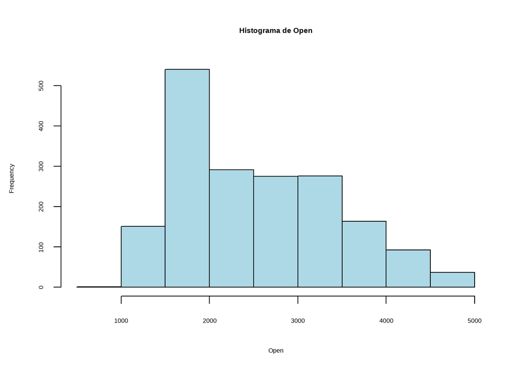

```r
hist(eth$Open,
     main = "Histograma de Open",
     xlab = "Open",
     col = "lightblue",
     border = "black")
```

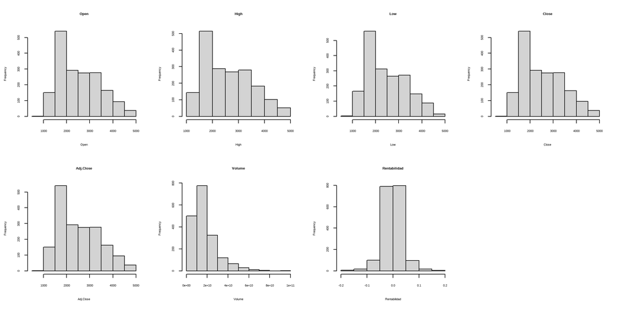

```r
par(mfrow = c(2, 4))

hist(eth$Open, main = "Open", xlab = "Open")
hist(eth$High, main = "High", xlab = "High")
hist(eth$Low, main = "Low", xlab = "Low")
hist(eth$Close, main = "Close", xlab = "Close")
hist(eth$Adj.Close, main = "Adj.Close", xlab = "Adj.Close")
hist(eth$Volume, main = "Volume", xlab = "Volume")
hist(eth$rentabilidad, main = "Rentabilidad", xlab = "Rentabilidad")

par(mfrow = c(1, 1))
```

### VIX (^VIX)

```r
vix <- read.csv("datos_csv/VIX.csv")
pander::pander(head(vix,10))
```

| Date | Open | High | Low | Close | Adj.Close | Volume |
| --- | --- | --- | --- | --- | --- | --- |
| 2021-09-07 | 16.94 | 18.39 | 16.89 | 18.14 | 18.14 | 0 |
| 2021-09-08 | 18.97 | 19.64 | 17.78 | 17.96 | 17.96 | 0 |
| 2021-09-09 | 19.44 | 19.54 | 17.17 | 18.8 | 18.8 | 0 |
| 2021-09-10 | 17.94 | 21.13 | 16.99 | 20.95 | 20.95 | 0 |
| 2021-09-13 | 19.64 | 21.18 | 18.76 | 19.37 | 19.37 | 0 |
| 2021-09-14 | 19.58 | 20.47 | 18.39 | 19.46 | 19.46 | 0 |
| 2021-09-15 | 19.3 | 20.27 | 18.01 | 18.18 | 18.18 | 0 |
| 2021-09-16 | 18.41 | 19.76 | 17.65 | 18.69 | 18.69 | 0 |
| 2021-09-17 | 18.37 | 21.51 | 18.35 | 20.81 | 20.81 | 0 |
| 2021-09-20 | 24.25 | 28.79 | 23.9 | 25.71 | 25.71 | 0 |

creamos la rentabilidad del periodo calculada como:

$$rentabilidad =
Ln\left(\frac{C_t}{C_{t-1}}\right)$$

```r
vix <- vix |>
  mutate(
    rentabilidad = log(Close / lag(Close))
  )
vix <- vix |>
  mutate(
    rent_porcent = round(rentabilidad*100,4)
  )
```

posteriormente de este analisis vamos a realizar el analisis exploratorio de la base.

```r
pander(diagnose(vix))
```

Table continues below

| variables | types | missing_count | missing_percent | unique_count |
| --- | --- | --- | --- | --- |
| Date | character | 0 | 0 | 1256 |
| Open | numeric | 0 | 0 | 855 |
| High | numeric | 0 | 0 | 911 |
| Low | numeric | 0 | 0 | 846 |
| Close | numeric | 0 | 0 | 866 |
| Adj.Close | numeric | 0 | 0 | 866 |
| Volume | integer | 0 | 0 | 1 |
| rentabilidad | numeric | 1 | 0.07962 | 1251 |
| rent_porcent | numeric | 1 | 0.07962 | 1245 |

| unique_rate |
| --- |
| 1 |
| 0.6807 |
| 0.7253 |
| 0.6736 |
| 0.6895 |
| 0.6895 |
| 0.0007962 |
| 0.996 |
| 0.9912 |

```r
pander(diagnose_outlier(vix))
```

Table continues below

| variables | outliers_cnt | outliers_ratio | outliers_mean | with_mean |
| --- | --- | --- | --- | --- |
| Open | 43 | 3.424 | 34.73 | 19.41 |
| High | 40 | 3.185 | 38.69 | 20.46 |
| Low | 45 | 3.583 | 31.39 | 18.4 |
| Close | 36 | 2.866 | 34.7 | 19.18 |
| Adj.Close | 36 | 2.866 | 34.7 | 19.18 |
| Volume | 0 | 0 | NA | 0 |
| rentabilidad | 49 | 3.901 | 0.09006 | -0.0001768 |
| rent_porcent | 49 | 3.901 | 9.006 | -0.01768 |

| without_mean |
| --- |
| 18.86 |
| 19.86 |
| 17.92 |
| 18.72 |
| 18.72 |
| 0 |
| -0.003843 |
| -0.3843 |

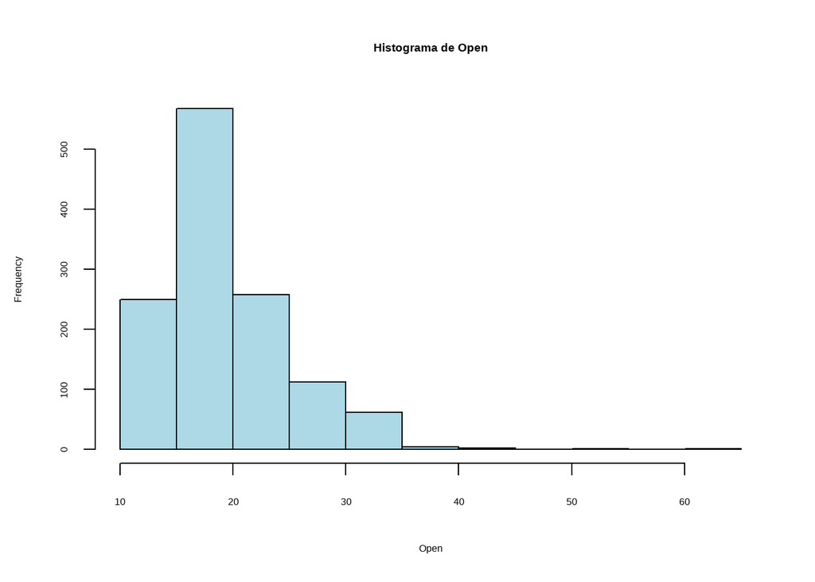

```r
hist(vix$Open,
     main = "Histograma de Open",
     xlab = "Open",
     col = "lightblue",
     border = "black")
```

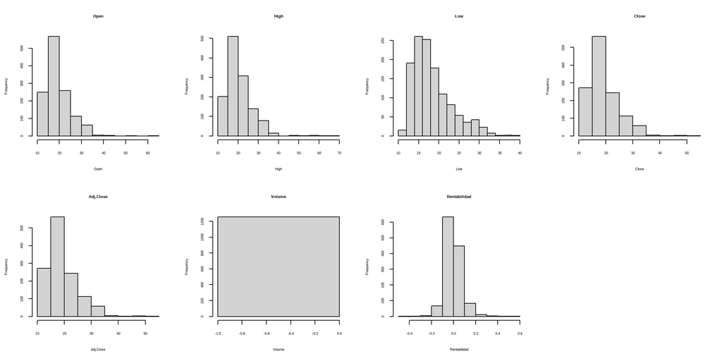

```r
par(mfrow = c(2, 4))

hist(vix$Open, main = "Open", xlab = "Open")
hist(vix$High, main = "High", xlab = "High")
hist(vix$Low, main = "Low", xlab = "Low")
hist(vix$Close, main = "Close", xlab = "Close")
hist(vix$Adj.Close, main = "Adj.Close", xlab = "Adj.Close")
hist(vix$Volume, main = "Volume", xlab = "Volume")
hist(vix$rentabilidad, main = "Rentabilidad", xlab = "Rentabilidad")

par(mfrow = c(1, 1))
```

### Short S&P 500 (SH)

```r
sh <- read.csv("datos_csv/SH.csv")
pander::pander(head(sh,10))
```

| Date | Open | High | Low | Close | Adj.Close | Volume |
| --- | --- | --- | --- | --- | --- | --- |
| 2021-09-07 | 58.04 | 58.32 | 58.04 | 58.2 | 48.83 | 775175 |
| 2021-09-08 | 58.28 | 58.56 | 58.16 | 58.28 | 48.9 | 1452975 |
| 2021-09-09 | 58.32 | 58.56 | 58.08 | 58.56 | 49.13 | 1475100 |
| 2021-09-10 | 58.24 | 59 | 58.2 | 59 | 49.5 | 1811575 |
| 2021-09-13 | 58.6 | 59.16 | 58.52 | 58.84 | 49.37 | 2307275 |
| 2021-09-14 | 58.6 | 59.28 | 58.6 | 59.12 | 49.6 | 1969150 |
| 2021-09-15 | 59.12 | 59.24 | 58.56 | 58.64 | 49.2 | 1910125 |
| 2021-09-16 | 58.76 | 59.16 | 58.6 | 58.76 | 49.3 | 1615550 |
| 2021-09-17 | 58.84 | 59.36 | 58.8 | 59.28 | 49.74 | 2401625 |
| 2021-09-20 | 60.2 | 61 | 59.96 | 60.32 | 50.61 | 6288225 |

creamos la rentabilidad del periodo calculada como:

$$rentabilidad =
Ln\left(\frac{C_t}{C_{t-1}}\right)$$

```r
sh <- sh |>
  mutate(
    rentabilidad = log(Close / lag(Close))
  )
sh <- sh |>
  mutate(
    rent_porcent = round(rentabilidad*100,4)
  )
```

posteriormente de este analisis vamos a realizar el analisis exploratorio de la base.

```r
pander(diagnose(sh))
```

Table continues below

| variables | types | missing_count | missing_percent | unique_count |
| --- | --- | --- | --- | --- |
| Date | character | 0 | 0 | 1255 |
| Open | numeric | 0 | 0 | 770 |
| High | numeric | 0 | 0 | 791 |
| Low | numeric | 0 | 0 | 760 |
| Close | numeric | 0 | 0 | 775 |
| Adj.Close | numeric | 0 | 0 | 969 |
| Volume | integer | 0 | 0 | 1251 |
| rentabilidad | numeric | 1 | 0.07968 | 1192 |
| rent_porcent | numeric | 1 | 0.07968 | 1176 |

| unique_rate |
| --- |
| 1 |
| 0.6135 |
| 0.6303 |
| 0.6056 |
| 0.6175 |
| 0.7721 |
| 0.9968 |
| 0.9498 |
| 0.9371 |

```r
pander(diagnose_outlier(sh))
```

Table continues below

| variables | outliers_cnt | outliers_ratio | outliers_mean | with_mean |
| --- | --- | --- | --- | --- |
| Open | 0 | 0 | NA | 49.66 |
| High | 0 | 0 | NA | 49.98 |
| Low | 0 | 0 | NA | 49.36 |
| Close | 0 | 0 | NA | 49.65 |
| Adj.Close | 0 | 0 | NA | 44.29 |
| Volume | 48 | 3.825 | 19793278 | 6925364 |
| rentabilidad | 58 | 4.622 | 0.002836 | -0.0004683 |
| rent_porcent | 58 | 4.622 | 0.2836 | -0.04683 |

| without_mean |
| --- |
| 49.66 |
| 49.98 |
| 49.36 |
| 49.65 |
| 44.29 |
| 6413632 |
| -0.0006286 |
| -0.06286 |

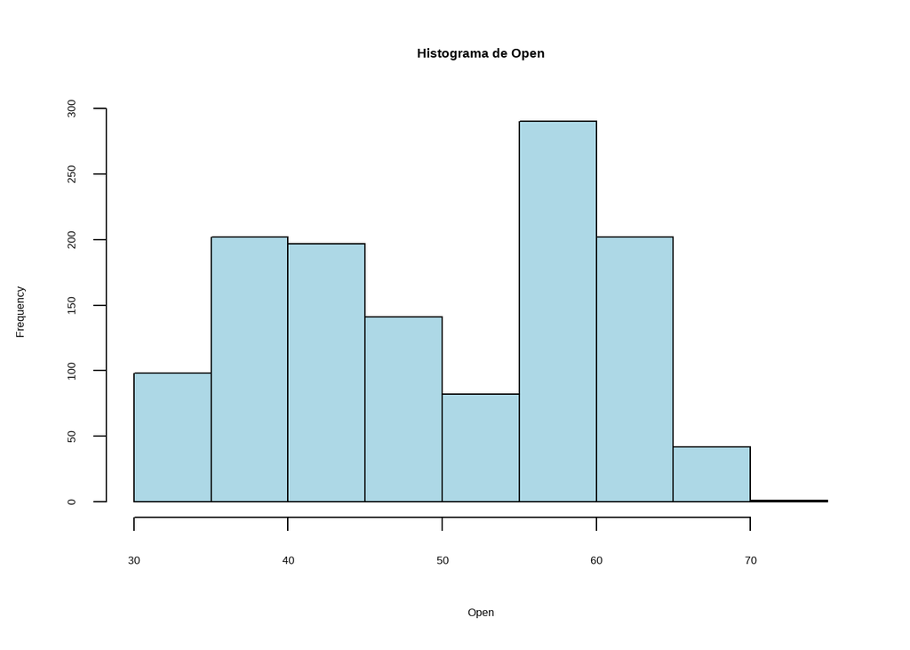

```r
hist(sh$Open,
     main = "Histograma de Open",
     xlab = "Open",
     col = "lightblue",
     border = "black")
```

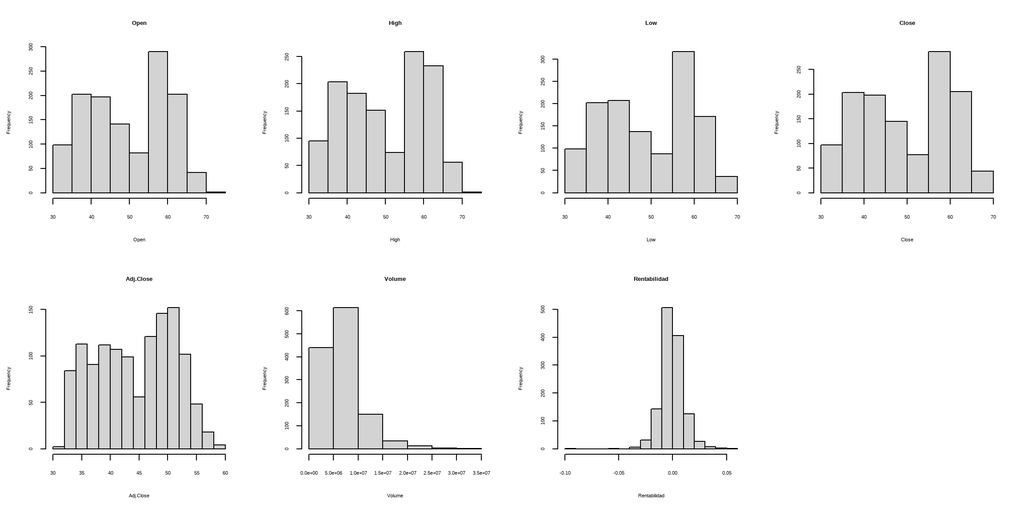

```r
par(mfrow = c(2, 4))

hist(sh$Open, main = "Open", xlab = "Open")
hist(sh$High, main = "High", xlab = "High")
hist(sh$Low, main = "Low", xlab = "Low")
hist(sh$Close, main = "Close", xlab = "Close")
hist(sh$Adj.Close, main = "Adj.Close", xlab = "Adj.Close")
hist(sh$Volume, main = "Volume", xlab = "Volume")
hist(sh$rentabilidad, main = "Rentabilidad", xlab = "Rentabilidad")

par(mfrow = c(1, 1))
```

### Short Nasdaq-100 (PSQ)

```r
psq <- read.csv("datos_csv/PSQ.csv")
pander::pander(head(psq,10))
```

| Date | Open | High | Low | Close | Adj.Close | Volume |
| --- | --- | --- | --- | --- | --- | --- |
| 2021-09-07 | 57.35 | 57.55 | 57.2 | 57.25 | 47.67 | 758000 |
| 2021-09-08 | 57.35 | 57.85 | 57.35 | 57.5 | 47.88 | 1201240 |
| 2021-09-09 | 57.4 | 57.75 | 57.25 | 57.7 | 48.05 | 645340 |
| 2021-09-10 | 57.45 | 58.2 | 57.3 | 58.15 | 48.42 | 923940 |
| 2021-09-13 | 57.75 | 58.5 | 57.65 | 58.15 | 48.42 | 1014260 |
| 2021-09-14 | 57.95 | 58.5 | 57.8 | 58.35 | 48.59 | 1028600 |
| 2021-09-15 | 58.3 | 58.6 | 57.8 | 57.9 | 48.21 | 940660 |
| 2021-09-16 | 58.05 | 58.4 | 57.75 | 57.85 | 48.17 | 831940 |
| 2021-09-17 | 57.9 | 58.7 | 57.9 | 58.45 | 48.67 | 1435900 |
| 2021-09-20 | 59.5 | 60.5 | 59.15 | 59.7 | 49.71 | 2765040 |

creamos la rentabilidad del periodo calculada como:

$$rentabilidad =
Ln\left(\frac{C_t}{C_{t-1}}\right)$$

```r
psq <- psq |>
  mutate(
    rentabilidad = log(Close / lag(Close))
  )
psq <- psq |>
  mutate(
    rent_porcent = round(rentabilidad*100,4)
  )
```

posteriormente de este analisis vamos a realizar el analisis exploratorio de la base.

```r
pander(diagnose(psq))
```

Table continues below

| variables | types | missing_count | missing_percent | unique_count |
| --- | --- | --- | --- | --- |
| Date | character | 0 | 0 | 1255 |
| Open | numeric | 0 | 0 | 906 |
| High | numeric | 0 | 0 | 900 |
| Low | numeric | 0 | 0 | 894 |
| Close | numeric | 0 | 0 | 888 |
| Adj.Close | numeric | 0 | 0 | 1029 |
| Volume | integer | 0 | 0 | 1251 |
| rentabilidad | numeric | 1 | 0.07968 | 1215 |
| rent_porcent | numeric | 1 | 0.07968 | 1203 |

| unique_rate |
| --- |
| 1 |
| 0.7219 |
| 0.7171 |
| 0.7124 |
| 0.7076 |
| 0.8199 |
| 0.9968 |
| 0.9681 |
| 0.9586 |

```r
pander(diagnose_outlier(psq))
```

Table continues below

| variables | outliers_cnt | outliers_ratio | outliers_mean | with_mean |
| --- | --- | --- | --- | --- |
| Open | 0 | 0 | NA | 47.59 |
| High | 0 | 0 | NA | 48.01 |
| Low | 0 | 0 | NA | 47.19 |
| Close | 0 | 0 | NA | 47.57 |
| Adj.Close | 0 | 0 | NA | 41.86 |
| Volume | 52 | 4.143 | 15765908 | 5771174 |
| rentabilidad | 43 | 3.426 | 0.005253 | -0.0006365 |
| rent_porcent | 43 | 3.426 | 0.5253 | -0.06365 |

| without_mean |
| --- |
| 47.59 |
| 48.01 |
| 47.19 |
| 47.57 |
| 41.86 |
| 5339149 |
| -0.0008456 |
| -0.08456 |

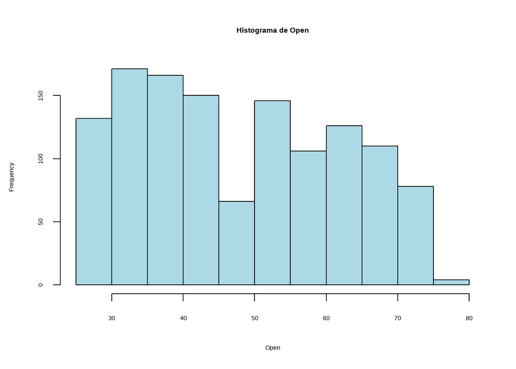

```r
hist(psq$Open,
     main = "Histograma de Open",
     xlab = "Open",
     col = "lightblue",
     border = "black")
```

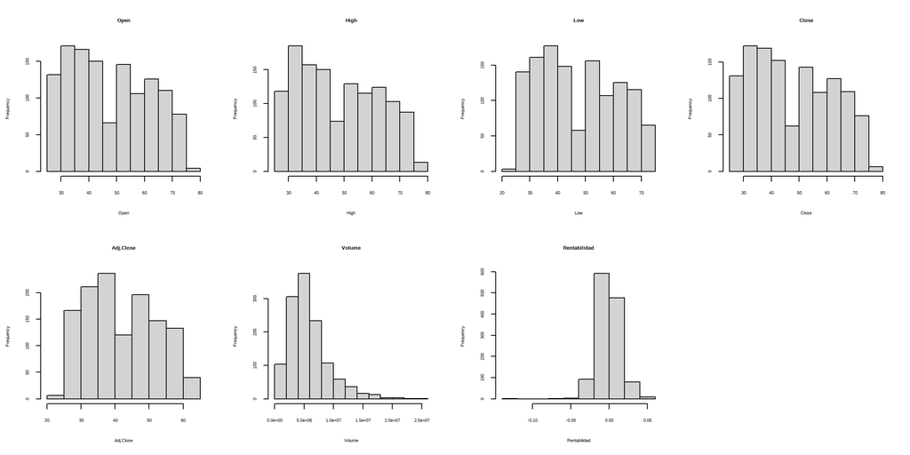

```r
par(mfrow = c(2, 4))

hist(psq$Open, main = "Open", xlab = "Open")
hist(psq$High, main = "High", xlab = "High")
hist(psq$Low, main = "Low", xlab = "Low")
hist(psq$Close, main = "Close", xlab = "Close")
hist(psq$Adj.Close, main = "Adj.Close", xlab = "Adj.Close")
hist(psq$Volume, main = "Volume", xlab = "Volume")
hist(psq$rentabilidad, main = "Rentabilidad", xlab = "Rentabilidad")

par(mfrow = c(1, 1))
```

### UltraShort oro (GLL)

```r
gll <- read.csv("datos_csv/GLL.csv")
pander::pander(head(gll,10))
```

| Date | Open | High | Low | Close | Adj.Close | Volume |
| --- | --- | --- | --- | --- | --- | --- |
| 2021-09-07 | 131.2 | 134 | 131 | 134 | 134 | 21525 |
| 2021-09-08 | 133.6 | 135.7 | 133.5 | 134.6 | 134.6 | 56075 |
| 2021-09-09 | 133.2 | 135.5 | 133.1 | 133.6 | 133.6 | 25725 |
| 2021-09-10 | 133.8 | 135 | 133.6 | 135 | 135 | 6725 |
| 2021-09-13 | 134.4 | 134.5 | 133.4 | 134.1 | 134.1 | 15400 |
| 2021-09-14 | 133.2 | 134.2 | 131.7 | 132.1 | 132.1 | 23025 |
| 2021-09-15 | 133.2 | 134.2 | 133.1 | 133.9 | 133.9 | 5225 |
| 2021-09-16 | 139.4 | 141.4 | 139.4 | 140 | 140 | 27325 |
| 2021-09-17 | 140.4 | 141.1 | 139.8 | 140.5 | 140.5 | 11775 |
| 2021-09-20 | 139.7 | 139.9 | 137.8 | 138.4 | 138.4 | 21750 |

creamos la rentabilidad del periodo calculada como:

$$rentabilidad =
Ln\left(\frac{C_t}{C_{t-1}}\right)$$

```r
gll <- gll |>
  mutate(
    rentabilidad = log(Close / lag(Close))
  )
gll <- gll |>
  mutate(
    rent_porcent = round(rentabilidad*100,4)
  )
```

posteriormente de este analisis vamos a realizar el analisis exploratorio de la base.

```r
pander(diagnose(gll))
```

Table continues below

| variables | types | missing_count | missing_percent | unique_count |
| --- | --- | --- | --- | --- |
| Date | character | 0 | 0 | 1255 |
| Open | numeric | 0 | 0 | 1011 |
| High | numeric | 0 | 0 | 1026 |
| Low | numeric | 0 | 0 | 1015 |
| Close | numeric | 0 | 0 | 1020 |
| Adj.Close | numeric | 0 | 0 | 1020 |
| Volume | integer | 0 | 0 | 1089 |
| rentabilidad | numeric | 1 | 0.07968 | 1238 |
| rent_porcent | numeric | 1 | 0.07968 | 1224 |

| unique_rate |
| --- |
| 1 |
| 0.8056 |
| 0.8175 |
| 0.8088 |
| 0.8127 |
| 0.8127 |
| 0.8677 |
| 0.9865 |
| 0.9753 |

```r
pander(diagnose_outlier(gll))
```

Table continues below

| variables | outliers_cnt | outliers_ratio | outliers_mean | with_mean |
| --- | --- | --- | --- | --- |
| Open | 0 | 0 | NA | 85.61 |
| High | 0 | 0 | NA | 86.34 |
| Low | 0 | 0 | NA | 84.87 |
| Close | 0 | 0 | NA | 85.58 |
| Adj.Close | 0 | 0 | NA | 85.58 |
| Volume | 241 | 19.2 | 4463314 | 924524 |
| rentabilidad | 54 | 4.303 | 0.001363 | -0.001446 |
| rent_porcent | 54 | 4.303 | 0.1363 | -0.1446 |

| without_mean |
| --- |
| 85.61 |
| 86.34 |
| 84.87 |
| 85.58 |
| 85.58 |
| 83451 |
| -0.001572 |
| -0.1572 |

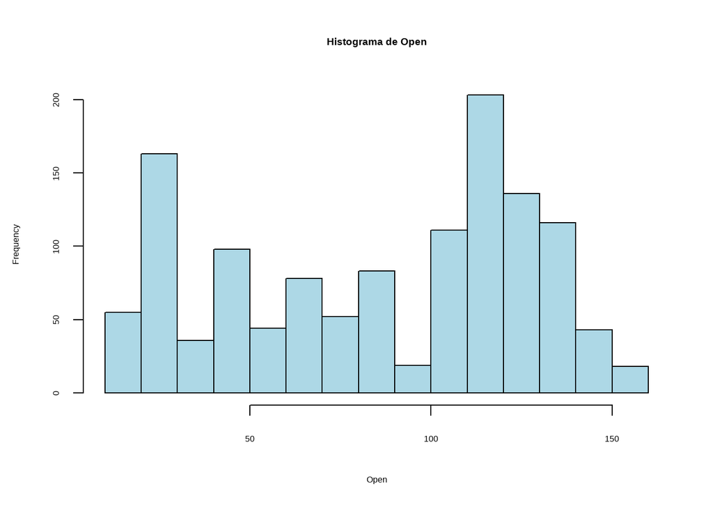

```r
hist(gll$Open,
     main = "Histograma de Open",
     xlab = "Open",
     col = "lightblue",
     border = "black")
```

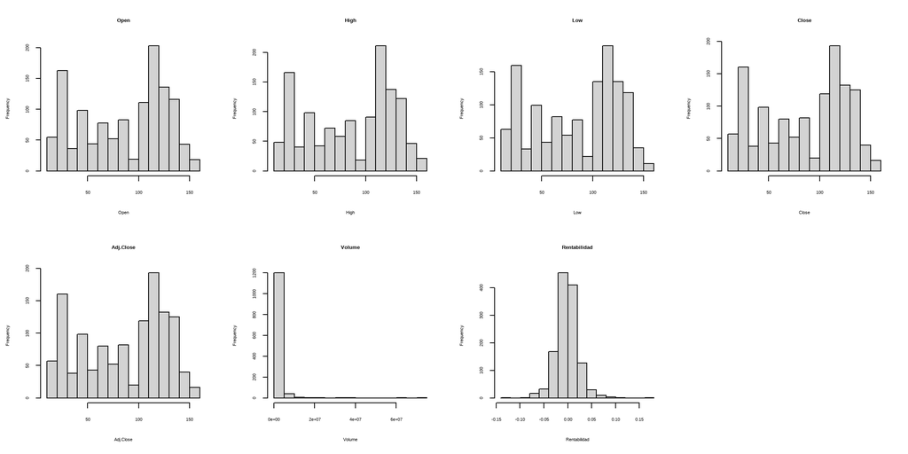

```r
par(mfrow = c(2, 4))

hist(gll$Open, main = "Open", xlab = "Open")
hist(gll$High, main = "High", xlab = "High")
hist(gll$Low, main = "Low", xlab = "Low")
hist(gll$Close, main = "Close", xlab = "Close")
hist(gll$Adj.Close, main = "Adj.Close", xlab = "Adj.Close")
hist(gll$Volume, main = "Volume", xlab = "Volume")
hist(gll$rentabilidad, main = "Rentabilidad", xlab = "Rentabilidad")

par(mfrow = c(1, 1))
```

## 8. Correlación entre los activos

Terminado el diagnóstico individual, se consolidan las rentabilidades logarítmicas de los veintiún activos para estudiar cómo se mueven unos respecto de otros.

Conforme a lo declarado en el apartado 6, las series se cruzan por fecha, se conservan las jornadas en que los veintiún activos tienen precio y los rendimientos se calculan sobre esos precios alineados. El número de rendimientos que resulta es el tamaño efectivo de la muestra sobre la que se calculan todos los coeficientes de este apartado y del siguiente. El vector `clases` agrupa los activos en los ocho estratos del diseño y se utiliza en los gráficos.

```r
activos <- list(
  "Tesla"                = tesla,
  "Google"               = google,
  "Microsoft"            = microsoft,
  "Petroleo WTI"         = petroleo,
  "Gas natural"          = gas,
  "Oro"                  = oro,
  "Diamante (proxy)"     = diamante,
  "S&P 500"              = sp500,
  "STOXX Europe 600"     = stoxx,
  "Nasdaq 100 (QQQ)"     = qqq,
  "Plata"                = plata,
  "Cobre"                = cobre,
  "Bonos Tesoro 20+"     = tlt,
  "Indice dolar"         = dolar,
  "Euro (FXE)"           = euro,
  "Bitcoin"              = btc,
  "Ethereum"             = eth,
  "VIX"                  = vix,
  "Short S&P 500 (SH)"   = sh,
  "Short Nasdaq (PSQ)"   = psq,
  "UltraShort Oro (GLL)" = gll
)

clases <- c(
  "Tesla"                = "Acciones",
  "Google"               = "Acciones",
  "Microsoft"            = "Acciones",
  "Diamante (proxy)"     = "Acciones",
  "S&P 500"              = "Indices",
  "STOXX Europe 600"     = "Indices",
  "Nasdaq 100 (QQQ)"     = "Indices",
  "Petroleo WTI"         = "Materias primas",
  "Gas natural"          = "Materias primas",
  "Oro"                  = "Materias primas",
  "Plata"                = "Materias primas",
  "Cobre"                = "Materias primas",
  "Bonos Tesoro 20+"     = "Renta fija",
  "Indice dolar"         = "Divisas",
  "Euro (FXE)"           = "Divisas",
  "Bitcoin"              = "Criptoactivos",
  "Ethereum"             = "Criptoactivos",
  "VIX"                  = "Volatilidad",
  "Short S&P 500 (SH)"   = "Inversos",
  "Short Nasdaq (PSQ)"   = "Inversos",
  "UltraShort Oro (GLL)" = "Inversos"
)

precios <- map_dfr(names(activos), function(nombre) {
  data.frame(
    Date   = as.Date(activos[[nombre]]$Date),
    Activo = nombre,
    Close  = activos[[nombre]]$Close
  )
}) |>
  pivot_wider(names_from = Activo, values_from = Close) |>
  arrange(Date)

comunes <- precios[complete.cases(precios[ , names(activos)]), ]

X      <- apply(as.matrix(comunes[ , names(activos)]), 2, function(p) diff(log(p)))
fechas <- comunes$Date[-1]

pander(data.frame(
  Fechas_totales  = nrow(precios),
  Precios_comunes = nrow(comunes),
  Rendimientos    = nrow(X),
  Desde           = format(min(fechas)),
  Hasta           = format(max(fechas))
))
```

| Fechas_totales | Precios_comunes | Rendimientos | Desde | Hasta |
| --- | --- | --- | --- | --- |
| 1827 | 1223 | 1222 | 2021-09-08 | 2026-09-04 |

### Cierres asíncronos

Antes de calcular las correlaciones conviene medir el efecto de las distintas horas de cierre. La tabla compara la correlación de tres activos con el rendimiento del S&P 500 del mismo día y con el del día anterior.

```r
retardo <- map_dfr(c("STOXX Europe 600", "Bitcoin", "Ethereum"), function(nombre) {
  hoy <- X[-1, nombre]
  data.frame(
    Activo             = nombre,
    SP500_mismo_dia    = round(cor(hoy, X[-1, "S&P 500"], method = "spearman"), 3),
    SP500_dia_anterior = round(cor(hoy, X[-nrow(X), "S&P 500"], method = "spearman"), 3)
  )
})

pander(retardo)
```

| Activo | SP500_mismo_dia | SP500_dia_anterior |
| --- | --- | --- |
| STOXX Europe 600 | 0.487 | 0.189 |
| Bitcoin | 0.396 | -0.092 |
| Ethereum | 0.411 | -0.053 |

El STOXX Europe 600 conserva una correlación de 0,189 con el S&P 500 del día anterior: parte de lo que ocurre en la tarde estadounidense se incorpora al índice europeo en la sesión siguiente, por lo que sus coeficientes contemporáneos subestiman el vínculo real entre ambos mercados. En los criptoactivos la correlación con el día anterior es prácticamente nula (−0,092 en bitcoin y −0,053 en ethereum), porque cierran después que la bolsa estadounidense y ya incorporan lo ocurrido en ella.

### Correlación de Spearman

Se utiliza el coeficiente de Spearman porque trabaja sobre rangos y no sobre los valores originales, lo que lo hace robusto frente a los valores extremos que el `diagnose_outlier` detectó en todos los activos.

```r
spearman <- cor(X, method = "spearman")
pander(round(spearman, 3))
```

Table continues below

|  | Tesla | Google | Microsoft | Petroleo WTI |
| --- | --- | --- | --- | --- |
| **Tesla** | 1 | 0.433 | 0.409 | 0.011 |
| **Google** | 0.433 | 1 | 0.602 | 0.002 |
| **Microsoft** | 0.409 | 0.602 | 1 | 0.01 |
| **Petroleo WTI** | 0.011 | 0.002 | 0.01 | 1 |
| **Gas natural** | 0.032 | 0.031 | 0.041 | 0.095 |
| **Oro** | 0.04 | 0.094 | 0.022 | 0.091 |
| **Diamante (proxy)** | 0.284 | 0.267 | 0.199 | 0.125 |
| **S&P 500** | 0.586 | 0.674 | 0.706 | 0.019 |
| **STOXX Europe 600** | 0.265 | 0.266 | 0.275 | 0.019 |
| **Nasdaq 100 (QQQ)** | 0.639 | 0.708 | 0.738 | -0.002 |
| **Plata** | 0.124 | 0.164 | 0.112 | 0.119 |
| **Cobre** | 0.188 | 0.17 | 0.132 | 0.193 |
| **Bonos Tesoro 20+** | 0.031 | 0.05 | 0.037 | -0.195 |
| **Indice dolar** | -0.154 | -0.182 | -0.143 | -0.002 |
| **Euro (FXE)** | 0.156 | 0.186 | 0.163 | -0.006 |
| **Bitcoin** | 0.36 | 0.308 | 0.302 | 0.032 |
| **Ethereum** | 0.362 | 0.329 | 0.312 | 0.023 |
| **VIX** | -0.473 | -0.495 | -0.514 | -0.009 |
| **Short S&P 500 (SH)** | -0.577 | -0.667 | -0.695 | -0.022 |
| **Short Nasdaq (PSQ)** | -0.636 | -0.7 | -0.731 | 0.004 |
| **UltraShort Oro (GLL)** | -0.061 | -0.119 | -0.049 | -0.116 |

Table continues below

|  | Gas natural | Oro | Diamante (proxy) | S&P 500 |
| --- | --- | --- | --- | --- |
| **Tesla** | 0.032 | 0.04 | 0.284 | 0.586 |
| **Google** | 0.031 | 0.094 | 0.267 | 0.674 |
| **Microsoft** | 0.041 | 0.022 | 0.199 | 0.706 |
| **Petroleo WTI** | 0.095 | 0.091 | 0.125 | 0.019 |
| **Gas natural** | 1 | 0.025 | 0.023 | 0.057 |
| **Oro** | 0.025 | 1 | 0.351 | 0.098 |
| **Diamante (proxy)** | 0.023 | 0.351 | 1 | 0.426 |
| **S&P 500** | 0.057 | 0.098 | 0.426 | 1 |
| **STOXX Europe 600** | 0.012 | 0.172 | 0.423 | 0.488 |
| **Nasdaq 100 (QQQ)** | 0.039 | 0.085 | 0.378 | 0.938 |
| **Plata** | 0.007 | 0.753 | 0.439 | 0.188 |
| **Cobre** | -0.006 | 0.411 | 0.571 | 0.272 |
| **Bonos Tesoro 20+** | -0.024 | 0.184 | 0.051 | 0.093 |
| **Indice dolar** | -0.005 | -0.415 | -0.385 | -0.274 |
| **Euro (FXE)** | 0.004 | 0.337 | 0.347 | 0.285 |
| **Bitcoin** | 0.003 | 0.113 | 0.254 | 0.396 |
| **Ethereum** | 0.004 | 0.097 | 0.252 | 0.411 |
| **VIX** | -0.038 | -0.056 | -0.374 | -0.759 |
| **Short S&P 500 (SH)** | -0.056 | -0.091 | -0.423 | -0.986 |
| **Short Nasdaq (PSQ)** | -0.039 | -0.075 | -0.376 | -0.932 |
| **UltraShort Oro (GLL)** | -0.026 | -0.903 | -0.36 | -0.139 |

Table continues below

|  | STOXX Europe 600 | Nasdaq 100 (QQQ) | Plata |
| --- | --- | --- | --- |
| **Tesla** | 0.265 | 0.639 | 0.124 |
| **Google** | 0.266 | 0.708 | 0.164 |
| **Microsoft** | 0.275 | 0.738 | 0.112 |
| **Petroleo WTI** | 0.019 | -0.002 | 0.119 |
| **Gas natural** | 0.012 | 0.039 | 0.007 |
| **Oro** | 0.172 | 0.085 | 0.753 |
| **Diamante (proxy)** | 0.423 | 0.378 | 0.439 |
| **S&P 500** | 0.488 | 0.938 | 0.188 |
| **STOXX Europe 600** | 1 | 0.415 | 0.27 |
| **Nasdaq 100 (QQQ)** | 0.415 | 1 | 0.181 |
| **Plata** | 0.27 | 0.181 | 1 |
| **Cobre** | 0.345 | 0.253 | 0.511 |
| **Bonos Tesoro 20+** | 0.06 | 0.077 | 0.096 |
| **Indice dolar** | -0.231 | -0.233 | -0.373 |
| **Euro (FXE)** | 0.188 | 0.248 | 0.318 |
| **Bitcoin** | 0.204 | 0.402 | 0.162 |
| **Ethereum** | 0.232 | 0.419 | 0.143 |
| **VIX** | -0.419 | -0.698 | -0.139 |
| **Short S&P 500 (SH)** | -0.482 | -0.925 | -0.189 |
| **Short Nasdaq (PSQ)** | -0.411 | -0.991 | -0.174 |
| **UltraShort Oro (GLL)** | -0.141 | -0.119 | -0.694 |

Table continues below

|  | Cobre | Bonos Tesoro 20+ | Indice dolar |
| --- | --- | --- | --- |
| **Tesla** | 0.188 | 0.031 | -0.154 |
| **Google** | 0.17 | 0.05 | -0.182 |
| **Microsoft** | 0.132 | 0.037 | -0.143 |
| **Petroleo WTI** | 0.193 | -0.195 | -0.002 |
| **Gas natural** | -0.006 | -0.024 | -0.005 |
| **Oro** | 0.411 | 0.184 | -0.415 |
| **Diamante (proxy)** | 0.571 | 0.051 | -0.385 |
| **S&P 500** | 0.272 | 0.093 | -0.274 |
| **STOXX Europe 600** | 0.345 | 0.06 | -0.231 |
| **Nasdaq 100 (QQQ)** | 0.253 | 0.077 | -0.233 |
| **Plata** | 0.511 | 0.096 | -0.373 |
| **Cobre** | 1 | 0.022 | -0.361 |
| **Bonos Tesoro 20+** | 0.022 | 1 | -0.256 |
| **Indice dolar** | -0.361 | -0.256 | 1 |
| **Euro (FXE)** | 0.315 | 0.204 | -0.939 |
| **Bitcoin** | 0.186 | -0.009 | -0.195 |
| **Ethereum** | 0.197 | -0.008 | -0.193 |
| **VIX** | -0.234 | -0.055 | 0.215 |
| **Short S&P 500 (SH)** | -0.274 | -0.094 | 0.268 |
| **Short Nasdaq (PSQ)** | -0.253 | -0.075 | 0.226 |
| **UltraShort Oro (GLL)** | -0.378 | -0.227 | 0.441 |

Table continues below

|  | Euro (FXE) | Bitcoin | Ethereum | VIX |
| --- | --- | --- | --- | --- |
| **Tesla** | 0.156 | 0.36 | 0.362 | -0.473 |
| **Google** | 0.186 | 0.308 | 0.329 | -0.495 |
| **Microsoft** | 0.163 | 0.302 | 0.312 | -0.514 |
| **Petroleo WTI** | -0.006 | 0.032 | 0.023 | -0.009 |
| **Gas natural** | 0.004 | 0.003 | 0.004 | -0.038 |
| **Oro** | 0.337 | 0.113 | 0.097 | -0.056 |
| **Diamante (proxy)** | 0.347 | 0.254 | 0.252 | -0.374 |
| **S&P 500** | 0.285 | 0.396 | 0.411 | -0.759 |
| **STOXX Europe 600** | 0.188 | 0.204 | 0.232 | -0.419 |
| **Nasdaq 100 (QQQ)** | 0.248 | 0.402 | 0.419 | -0.698 |
| **Plata** | 0.318 | 0.162 | 0.143 | -0.139 |
| **Cobre** | 0.315 | 0.186 | 0.197 | -0.234 |
| **Bonos Tesoro 20+** | 0.204 | -0.009 | -0.008 | -0.055 |
| **Indice dolar** | -0.939 | -0.195 | -0.193 | 0.215 |
| **Euro (FXE)** | 1 | 0.196 | 0.195 | -0.228 |
| **Bitcoin** | 0.196 | 1 | 0.837 | -0.336 |
| **Ethereum** | 0.195 | 0.837 | 1 | -0.374 |
| **VIX** | -0.228 | -0.336 | -0.374 | 1 |
| **Short S&P 500 (SH)** | -0.279 | -0.395 | -0.404 | 0.752 |
| **Short Nasdaq (PSQ)** | -0.242 | -0.404 | -0.416 | 0.697 |
| **UltraShort Oro (GLL)** | -0.388 | -0.147 | -0.119 | 0.086 |

Table continues below

|  | Short S&P 500 (SH) | Short Nasdaq (PSQ) |
| --- | --- | --- |
| **Tesla** | -0.577 | -0.636 |
| **Google** | -0.667 | -0.7 |
| **Microsoft** | -0.695 | -0.731 |
| **Petroleo WTI** | -0.022 | 0.004 |
| **Gas natural** | -0.056 | -0.039 |
| **Oro** | -0.091 | -0.075 |
| **Diamante (proxy)** | -0.423 | -0.376 |
| **S&P 500** | -0.986 | -0.932 |
| **STOXX Europe 600** | -0.482 | -0.411 |
| **Nasdaq 100 (QQQ)** | -0.925 | -0.991 |
| **Plata** | -0.189 | -0.174 |
| **Cobre** | -0.274 | -0.253 |
| **Bonos Tesoro 20+** | -0.094 | -0.075 |
| **Indice dolar** | 0.268 | 0.226 |
| **Euro (FXE)** | -0.279 | -0.242 |
| **Bitcoin** | -0.395 | -0.404 |
| **Ethereum** | -0.404 | -0.416 |
| **VIX** | 0.752 | 0.697 |
| **Short S&P 500 (SH)** | 1 | 0.937 |
| **Short Nasdaq (PSQ)** | 0.937 | 1 |
| **UltraShort Oro (GLL)** | 0.13 | 0.109 |

|  | UltraShort Oro (GLL) |
| --- | --- |
| **Tesla** | -0.061 |
| **Google** | -0.119 |
| **Microsoft** | -0.049 |
| **Petroleo WTI** | -0.116 |
| **Gas natural** | -0.026 |
| **Oro** | -0.903 |
| **Diamante (proxy)** | -0.36 |
| **S&P 500** | -0.139 |
| **STOXX Europe 600** | -0.141 |
| **Nasdaq 100 (QQQ)** | -0.119 |
| **Plata** | -0.694 |
| **Cobre** | -0.378 |
| **Bonos Tesoro 20+** | -0.227 |
| **Indice dolar** | 0.441 |
| **Euro (FXE)** | -0.388 |
| **Bitcoin** | -0.147 |
| **Ethereum** | -0.119 |
| **VIX** | 0.086 |
| **Short S&P 500 (SH)** | 0.13 |
| **Short Nasdaq (PSQ)** | 0.109 |
| **UltraShort Oro (GLL)** | 1 |

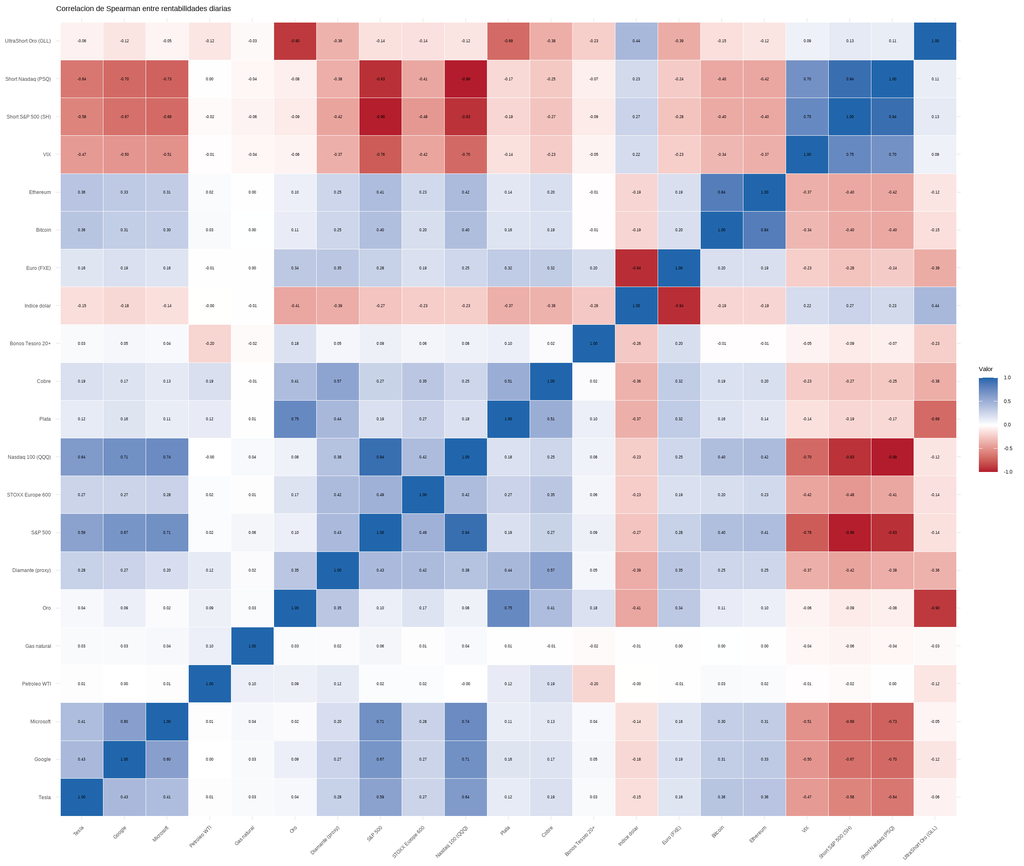

```r
mapa_calor <- function(m, titulo) {
  largo <- as.data.frame(as.table(m))
  colnames(largo) <- c("Activo1", "Activo2", "Valor")

  ggplot(largo, aes(Activo1, Activo2, fill = Valor)) +
    geom_tile(color = "white") +
    geom_text(aes(label = sprintf("%.2f", Valor)), size = 2.3) +
    scale_fill_gradient2(low = "#b2182b", mid = "white", high = "#2166ac",
                         midpoint = 0, limits = c(-1, 1)) +
    labs(title = titulo, x = NULL, y = NULL) +
    theme_minimal() +
    theme(axis.text.x = element_text(angle = 45, hjust = 1))
}

mapa_calor(spearman, "Correlacion de Spearman entre rentabilidades diarias")
```

### Pares con correlación negativa

Con veintiún activos la matriz contiene 210 pares distintos. La tabla ordena los doce con la correlación más negativa.

```r
pares <- which(upper.tri(spearman), arr.ind = TRUE)

todos_los_pares <- data.frame(
  Activo_1 = colnames(spearman)[pares[ , 1]],
  Activo_2 = colnames(spearman)[pares[ , 2]],
  Spearman = round(spearman[pares], 3)
)

todos_los_pares |>
  arrange(Spearman) |>
  head(12) |>
  pander()
```

| Activo_1 | Activo_2 | Spearman |
| --- | --- | --- |
| Nasdaq 100 (QQQ) | Short Nasdaq (PSQ) | -0.991 |
| S&P 500 | Short S&P 500 (SH) | -0.986 |
| Indice dolar | Euro (FXE) | -0.939 |
| S&P 500 | Short Nasdaq (PSQ) | -0.932 |
| Nasdaq 100 (QQQ) | Short S&P 500 (SH) | -0.925 |
| Oro | UltraShort Oro (GLL) | -0.903 |
| S&P 500 | VIX | -0.759 |
| Microsoft | Short Nasdaq (PSQ) | -0.731 |
| Google | Short Nasdaq (PSQ) | -0.7 |
| Nasdaq 100 (QQQ) | VIX | -0.698 |
| Microsoft | Short S&P 500 (SH) | -0.695 |
| Plata | UltraShort Oro (GLL) | -0.694 |

### Correlación de distancias

El coeficiente de Spearman solo detecta relaciones monótonas: si dos activos se mueven juntos en magnitud pero sin una dirección consistente, Spearman devuelve un valor cercano a cero. La correlación de distancias resuelve esa limitación, ya que vale cero **si y solo si** las dos variables son independientes, e identifica también dependencias no lineales. Su rango va de 0 a 1 y no toma valores negativos, de modo que una relación inversa perfecta aparece en ella con un valor cercano a 1.

```r
k  <- ncol(X)
dc <- matrix(1, k, k, dimnames = list(colnames(X), colnames(X)))

for (i in 1:(k - 1)) {
  for (j in (i + 1):k) {
    valor    <- dcor(X[ , i], X[ , j])
    dc[i, j] <- valor
    dc[j, i] <- valor
  }
}

pander(round(dc, 3))
```

Table continues below

|  | Tesla | Google | Microsoft | Petroleo WTI |
| --- | --- | --- | --- | --- |
| **Tesla** | 1 | 0.41 | 0.387 | 0.05 |
| **Google** | 0.41 | 1 | 0.582 | 0.055 |
| **Microsoft** | 0.387 | 0.582 | 1 | 0.061 |
| **Petroleo WTI** | 0.05 | 0.055 | 0.061 | 1 |
| **Gas natural** | 0.064 | 0.059 | 0.071 | 0.105 |
| **Oro** | 0.066 | 0.104 | 0.065 | 0.11 |
| **Diamante (proxy)** | 0.267 | 0.258 | 0.2 | 0.141 |
| **S&P 500** | 0.559 | 0.651 | 0.687 | 0.089 |
| **STOXX Europe 600** | 0.255 | 0.259 | 0.267 | 0.09 |
| **Nasdaq 100 (QQQ)** | 0.609 | 0.683 | 0.716 | 0.077 |
| **Plata** | 0.128 | 0.162 | 0.124 | 0.128 |
| **Cobre** | 0.181 | 0.168 | 0.138 | 0.194 |
| **Bonos Tesoro 20+** | 0.07 | 0.071 | 0.065 | 0.205 |
| **Indice dolar** | 0.152 | 0.182 | 0.153 | 0.06 |
| **Euro (FXE)** | 0.156 | 0.185 | 0.169 | 0.063 |
| **Bitcoin** | 0.34 | 0.289 | 0.295 | 0.054 |
| **Ethereum** | 0.348 | 0.311 | 0.307 | 0.064 |
| **VIX** | 0.454 | 0.478 | 0.497 | 0.08 |
| **Short S&P 500 (SH)** | 0.55 | 0.643 | 0.675 | 0.09 |
| **Short Nasdaq (PSQ)** | 0.606 | 0.676 | 0.709 | 0.078 |
| **UltraShort Oro (GLL)** | 0.084 | 0.13 | 0.086 | 0.124 |

Table continues below

|  | Gas natural | Oro | Diamante (proxy) | S&P 500 |
| --- | --- | --- | --- | --- |
| **Tesla** | 0.064 | 0.066 | 0.267 | 0.559 |
| **Google** | 0.059 | 0.104 | 0.258 | 0.651 |
| **Microsoft** | 0.071 | 0.065 | 0.2 | 0.687 |
| **Petroleo WTI** | 0.105 | 0.11 | 0.141 | 0.089 |
| **Gas natural** | 1 | 0.054 | 0.051 | 0.077 |
| **Oro** | 0.054 | 1 | 0.333 | 0.109 |
| **Diamante (proxy)** | 0.051 | 0.333 | 1 | 0.409 |
| **S&P 500** | 0.077 | 0.109 | 0.409 | 1 |
| **STOXX Europe 600** | 0.06 | 0.176 | 0.404 | 0.469 |
| **Nasdaq 100 (QQQ)** | 0.064 | 0.097 | 0.365 | 0.925 |
| **Plata** | 0.051 | 0.725 | 0.421 | 0.188 |
| **Cobre** | 0.048 | 0.389 | 0.544 | 0.26 |
| **Bonos Tesoro 20+** | 0.06 | 0.175 | 0.075 | 0.12 |
| **Indice dolar** | 0.06 | 0.389 | 0.37 | 0.27 |
| **Euro (FXE)** | 0.053 | 0.317 | 0.333 | 0.28 |
| **Bitcoin** | 0.057 | 0.117 | 0.24 | 0.378 |
| **Ethereum** | 0.057 | 0.106 | 0.239 | 0.396 |
| **VIX** | 0.058 | 0.087 | 0.363 | 0.743 |
| **Short S&P 500 (SH)** | 0.076 | 0.105 | 0.405 | 0.986 |
| **Short Nasdaq (PSQ)** | 0.064 | 0.091 | 0.362 | 0.918 |
| **UltraShort Oro (GLL)** | 0.053 | 0.888 | 0.349 | 0.151 |

Table continues below

|  | STOXX Europe 600 | Nasdaq 100 (QQQ) | Plata | Cobre |
| --- | --- | --- | --- | --- |
| **Tesla** | 0.255 | 0.609 | 0.128 | 0.181 |
| **Google** | 0.259 | 0.683 | 0.162 | 0.168 |
| **Microsoft** | 0.267 | 0.716 | 0.124 | 0.138 |
| **Petroleo WTI** | 0.09 | 0.077 | 0.128 | 0.194 |
| **Gas natural** | 0.06 | 0.064 | 0.051 | 0.048 |
| **Oro** | 0.176 | 0.097 | 0.725 | 0.389 |
| **Diamante (proxy)** | 0.404 | 0.365 | 0.421 | 0.544 |
| **S&P 500** | 0.469 | 0.925 | 0.188 | 0.26 |
| **STOXX Europe 600** | 1 | 0.399 | 0.261 | 0.331 |
| **Nasdaq 100 (QQQ)** | 0.399 | 1 | 0.184 | 0.241 |
| **Plata** | 0.261 | 0.184 | 1 | 0.49 |
| **Cobre** | 0.331 | 0.241 | 0.49 | 1 |
| **Bonos Tesoro 20+** | 0.089 | 0.103 | 0.098 | 0.055 |
| **Indice dolar** | 0.228 | 0.232 | 0.346 | 0.339 |
| **Euro (FXE)** | 0.191 | 0.244 | 0.297 | 0.3 |
| **Bitcoin** | 0.201 | 0.383 | 0.156 | 0.175 |
| **Ethereum** | 0.228 | 0.402 | 0.141 | 0.188 |
| **VIX** | 0.406 | 0.681 | 0.146 | 0.231 |
| **Short S&P 500 (SH)** | 0.464 | 0.911 | 0.187 | 0.261 |
| **Short Nasdaq (PSQ)** | 0.395 | 0.99 | 0.177 | 0.241 |
| **UltraShort Oro (GLL)** | 0.149 | 0.135 | 0.665 | 0.363 |

Table continues below

|  | Bonos Tesoro 20+ | Indice dolar | Euro (FXE) |
| --- | --- | --- | --- |
| **Tesla** | 0.07 | 0.152 | 0.156 |
| **Google** | 0.071 | 0.182 | 0.185 |
| **Microsoft** | 0.065 | 0.153 | 0.169 |
| **Petroleo WTI** | 0.205 | 0.06 | 0.063 |
| **Gas natural** | 0.06 | 0.06 | 0.053 |
| **Oro** | 0.175 | 0.389 | 0.317 |
| **Diamante (proxy)** | 0.075 | 0.37 | 0.333 |
| **S&P 500** | 0.12 | 0.27 | 0.28 |
| **STOXX Europe 600** | 0.089 | 0.228 | 0.191 |
| **Nasdaq 100 (QQQ)** | 0.103 | 0.232 | 0.244 |
| **Plata** | 0.098 | 0.346 | 0.297 |
| **Cobre** | 0.055 | 0.339 | 0.3 |
| **Bonos Tesoro 20+** | 1 | 0.249 | 0.205 |
| **Indice dolar** | 0.249 | 1 | 0.925 |
| **Euro (FXE)** | 0.205 | 0.925 | 1 |
| **Bitcoin** | 0.054 | 0.184 | 0.188 |
| **Ethereum** | 0.053 | 0.185 | 0.191 |
| **VIX** | 0.087 | 0.208 | 0.218 |
| **Short S&P 500 (SH)** | 0.12 | 0.265 | 0.275 |
| **Short Nasdaq (PSQ)** | 0.101 | 0.227 | 0.241 |
| **UltraShort Oro (GLL)** | 0.213 | 0.414 | 0.366 |

Table continues below

|  | Bitcoin | Ethereum | VIX | Short S&P 500 (SH) |
| --- | --- | --- | --- | --- |
| **Tesla** | 0.34 | 0.348 | 0.454 | 0.55 |
| **Google** | 0.289 | 0.311 | 0.478 | 0.643 |
| **Microsoft** | 0.295 | 0.307 | 0.497 | 0.675 |
| **Petroleo WTI** | 0.054 | 0.064 | 0.08 | 0.09 |
| **Gas natural** | 0.057 | 0.057 | 0.058 | 0.076 |
| **Oro** | 0.117 | 0.106 | 0.087 | 0.105 |
| **Diamante (proxy)** | 0.24 | 0.239 | 0.363 | 0.405 |
| **S&P 500** | 0.378 | 0.396 | 0.743 | 0.986 |
| **STOXX Europe 600** | 0.201 | 0.228 | 0.406 | 0.464 |
| **Nasdaq 100 (QQQ)** | 0.383 | 0.402 | 0.681 | 0.911 |
| **Plata** | 0.156 | 0.141 | 0.146 | 0.187 |
| **Cobre** | 0.175 | 0.188 | 0.231 | 0.261 |
| **Bonos Tesoro 20+** | 0.054 | 0.053 | 0.087 | 0.12 |
| **Indice dolar** | 0.184 | 0.185 | 0.208 | 0.265 |
| **Euro (FXE)** | 0.188 | 0.191 | 0.218 | 0.275 |
| **Bitcoin** | 1 | 0.814 | 0.327 | 0.378 |
| **Ethereum** | 0.814 | 1 | 0.368 | 0.391 |
| **VIX** | 0.327 | 0.368 | 1 | 0.736 |
| **Short S&P 500 (SH)** | 0.378 | 0.391 | 0.736 | 1 |
| **Short Nasdaq (PSQ)** | 0.384 | 0.399 | 0.678 | 0.923 |
| **UltraShort Oro (GLL)** | 0.145 | 0.127 | 0.119 | 0.145 |

|  | Short Nasdaq (PSQ) | UltraShort Oro (GLL) |
| --- | --- | --- |
| **Tesla** | 0.606 | 0.084 |
| **Google** | 0.676 | 0.13 |
| **Microsoft** | 0.709 | 0.086 |
| **Petroleo WTI** | 0.078 | 0.124 |
| **Gas natural** | 0.064 | 0.053 |
| **Oro** | 0.091 | 0.888 |
| **Diamante (proxy)** | 0.362 | 0.349 |
| **S&P 500** | 0.918 | 0.151 |
| **STOXX Europe 600** | 0.395 | 0.149 |
| **Nasdaq 100 (QQQ)** | 0.99 | 0.135 |
| **Plata** | 0.177 | 0.665 |
| **Cobre** | 0.241 | 0.363 |
| **Bonos Tesoro 20+** | 0.101 | 0.213 |
| **Indice dolar** | 0.227 | 0.414 |
| **Euro (FXE)** | 0.241 | 0.366 |
| **Bitcoin** | 0.384 | 0.145 |
| **Ethereum** | 0.399 | 0.127 |
| **VIX** | 0.678 | 0.119 |
| **Short S&P 500 (SH)** | 0.923 | 0.145 |
| **Short Nasdaq (PSQ)** | 1 | 0.129 |
| **UltraShort Oro (GLL)** | 0.129 | 1 |

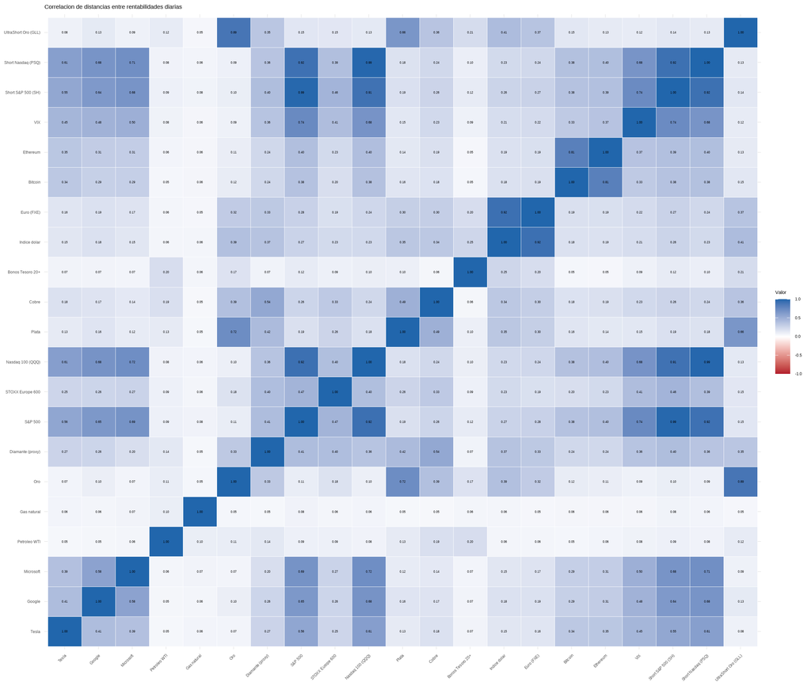

```r
mapa_calor(dc, "Correlacion de distancias entre rentabilidades diarias")
```

### Spearman frente a correlación de distancias

Comparar ambos coeficientes permite detectar pares de activos con dependencia no monótona: si la correlación de distancias es claramente mayor que el valor absoluto de Spearman, existe una relación que el coeficiente de rangos no captura.

```r
comparacion <- data.frame(
  Activo_1  = colnames(spearman)[pares[ , 1]],
  Activo_2  = colnames(spearman)[pares[ , 2]],
  Spearman  = round(spearman[pares], 3),
  Distancia = round(dc[pares], 3)
) |>
  mutate(Diferencia = round(Distancia - abs(Spearman), 3)) |>
  arrange(desc(Diferencia))

pander(head(comparacion, 12))
```

| Activo_1 | Activo_2 | Spearman | Distancia | Diferencia |
| --- | --- | --- | --- | --- |
| Petroleo WTI | Nasdaq 100 (QQQ) | -0.002 | 0.077 | 0.075 |
| Petroleo WTI | Short Nasdaq (PSQ) | 0.004 | 0.078 | 0.074 |
| Petroleo WTI | STOXX Europe 600 | 0.019 | 0.09 | 0.071 |
| Petroleo WTI | VIX | -0.009 | 0.08 | 0.071 |
| Petroleo WTI | S&P 500 | 0.019 | 0.089 | 0.07 |
| Petroleo WTI | Short S&P 500 (SH) | -0.022 | 0.09 | 0.068 |
| Petroleo WTI | Indice dolar | -0.002 | 0.06 | 0.058 |
| Petroleo WTI | Euro (FXE) | -0.006 | 0.063 | 0.057 |
| Gas natural | Indice dolar | -0.005 | 0.06 | 0.055 |
| Gas natural | Bitcoin | 0.003 | 0.057 | 0.054 |
| Google | Petroleo WTI | 0.002 | 0.055 | 0.053 |
| Gas natural | Ethereum | 0.004 | 0.057 | 0.053 |

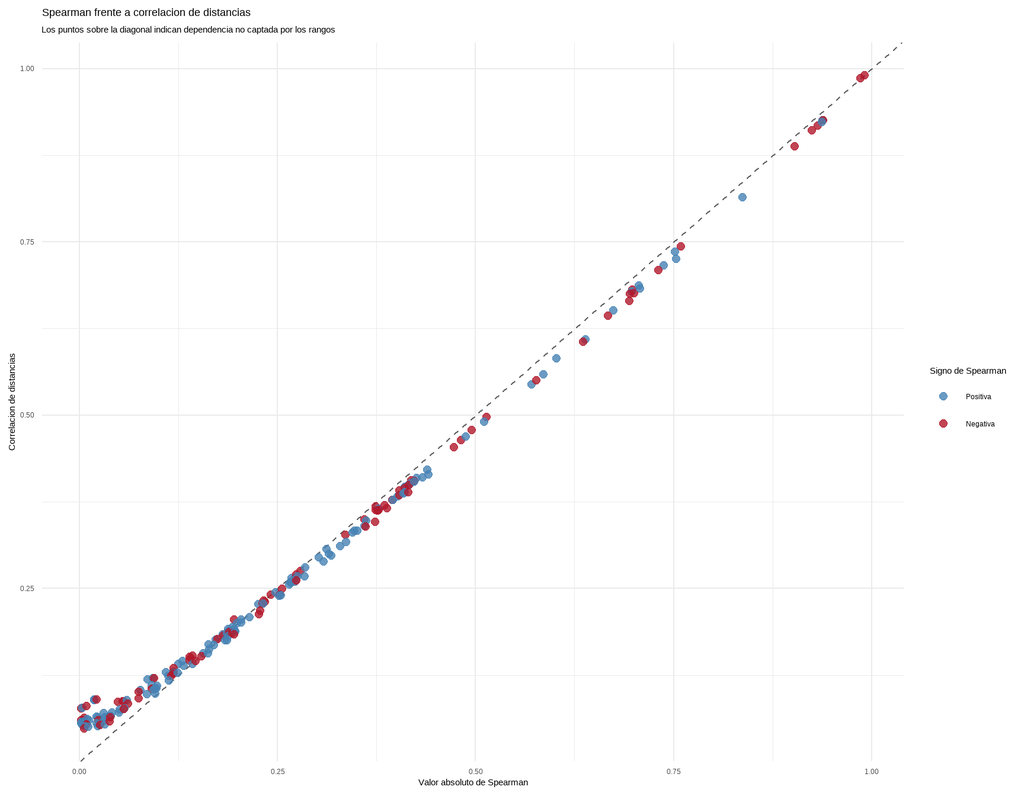

```r
ggplot(comparacion, aes(x = abs(Spearman), y = Distancia, color = Spearman < 0)) +
  geom_abline(slope = 1, intercept = 0, linetype = "dashed", color = "grey40") +
  geom_point(size = 2.2, alpha = 0.8) +
  scale_color_manual(values = c("FALSE" = "steelblue", "TRUE" = "#b2182b"),
                     labels = c("Positiva", "Negativa"),
                     name   = "Signo de Spearman") +
  labs(
    title    = "Spearman frente a correlacion de distancias",
    subtitle = "Los puntos sobre la diagonal indican dependencia no captada por los rangos",
    x        = "Valor absoluto de Spearman",
    y        = "Correlacion de distancias"
  ) +
  theme_minimal()
```

### Sesgo de la correlación de distancias

El estimador muestral de la correlación de distancias no vale cero cuando dos variables son independientes: tiene un sesgo positivo que depende del tamaño de la muestra y de la forma de las distribuciones. Para saber a partir de qué valor el coeficiente refleja dependencia real se construye una línea base: se permuta al azar el orden de una de las series, lo que rompe cualquier relación con la otra, y se recalcula el coeficiente cien veces. La línea base se construye sobre el par petróleo y S&P 500, por lo que funciona como una aproximación para el resto de los pares.

```r
set.seed(123)
linea_base <- replicate(100, dcor(X[ , "Petroleo WTI"], sample(X[ , "S&P 500"])))
umbral     <- unname(quantile(linea_base, 0.95))

pander(data.frame(
  Media_bajo_independencia = round(mean(linea_base), 3),
  Percentil_95             = round(umbral, 3)
))
```

| Media_bajo_independencia | Percentil_95 |
| --- | --- |
| 0.054 | 0.074 |

```r
comparacion |>
  head(12) |>
  mutate(Supera_linea_base = ifelse(Distancia > umbral, "Si", "No")) |>
  pander()
```

Table continues below

| Activo_1 | Activo_2 | Spearman | Distancia | Diferencia |
| --- | --- | --- | --- | --- |
| Petroleo WTI | Nasdaq 100 (QQQ) | -0.002 | 0.077 | 0.075 |
| Petroleo WTI | Short Nasdaq (PSQ) | 0.004 | 0.078 | 0.074 |
| Petroleo WTI | STOXX Europe 600 | 0.019 | 0.09 | 0.071 |
| Petroleo WTI | VIX | -0.009 | 0.08 | 0.071 |
| Petroleo WTI | S&P 500 | 0.019 | 0.089 | 0.07 |
| Petroleo WTI | Short S&P 500 (SH) | -0.022 | 0.09 | 0.068 |
| Petroleo WTI | Indice dolar | -0.002 | 0.06 | 0.058 |
| Petroleo WTI | Euro (FXE) | -0.006 | 0.063 | 0.057 |
| Gas natural | Indice dolar | -0.005 | 0.06 | 0.055 |
| Gas natural | Bitcoin | 0.003 | 0.057 | 0.054 |
| Google | Petroleo WTI | 0.002 | 0.055 | 0.053 |
| Gas natural | Ethereum | 0.004 | 0.057 | 0.053 |

| Supera_linea_base |
| --- |
| Si |
| Si |
| Si |
| Si |
| Si |
| Si |
| No |
| No |
| No |
| No |
| No |
| No |

### Análisis de las correlaciones

Con veintiún activos la matriz de Spearman se organiza en bloques nítidos. El más compacto es el de la renta variable estadounidense: el S&P 500 y el Nasdaq-100 forman el par positivo más alto de toda la matriz (0,938), y las tres tecnológicas correlacionan entre 0,639 y 0,738 con el Nasdaq-100. Los criptoactivos forman un bloque propio, con 0,837 entre bitcoin y ethereum, y lo mismo ocurre con los metales preciosos, con 0,753 entre el oro y la plata.

Seis pares tienen una correlación inferior a −0,9, y los productos inversos explican cinco de ellos. SH frente al S&P 500 (−0,986) y PSQ frente al Nasdaq-100 (−0,991) replican casi exactamente su diseño, y los cruces entre ellos también quedan por debajo de −0,9 porque ambos índices se mueven casi juntos. GLL frente al oro alcanza −0,903, una cifra algo menos extrema, que puede deberse a que el fondo y el futuro continuo no siguen exactamente el mismo contrato ni cierran a la misma hora. El único par natural por debajo de −0,9 es el del índice del dólar frente al euro (−0,939), y tiene una explicación estructural: el euro representa cerca del 58 % de la canasta con la que se calcula el índice, de modo que este se comporta en buena medida como el reflejo del tipo de cambio entre ambas monedas.

## 9. Rendimientos frente al S&P 500

En este apartado se toma el S&P 500 como referencia de mercado y se evalúa el comportamiento de los otros veinte activos frente a él. Para cada activo se estima la regresión `r_activo = alfa + beta * r_sp500 + error` sobre las rentabilidades diarias, y se reportan también la rentabilidad acumulada y la volatilidad anualizada del periodo.

El coeficiente beta mide la sensibilidad del activo a los movimientos del índice: un beta de 2 implica que, en promedio, el activo amplifica al doble los movimientos del mercado, y un beta negativo indica que se mueve en sentido contrario. El coeficiente de determinación indica qué proporción de la variabilidad del activo queda explicada por el índice. El intercepto anualizado recoge el rendimiento medio no atribuible al mercado; conviene advertir que se calcula sin descontar una tasa libre de riesgo, por lo que es una medida descriptiva y no un alfa de Jensen.

```r
benchmark <- X[ , "S&P 500"]
otros     <- setdiff(colnames(X), "S&P 500")

frente_sp <- map_dfr(otros, function(nombre) {
  r      <- X[ , nombre]
  modelo <- lm(r ~ benchmark)
  data.frame(
    Activo           = nombre,
    Spearman         = round(cor(r, benchmark, method = "spearman"), 3),
    Distancia        = round(dc[nombre, "S&P 500"], 3),
    Beta             = round(unname(coef(modelo)[2]), 3),
    R2               = round(summary(modelo)$r.squared, 3),
    Intercepto_anual = round(unname(coef(modelo)[1]) * 252 * 100, 2),
    Rend_acum        = round((exp(sum(r)) - 1) * 100, 1),
    Vol_anual        = round(sd(r) * sqrt(252) * 100, 1),
    row.names        = NULL
  )
}) |>
  arrange(desc(Rend_acum))

pander(frente_sp)
```

Table continues below

| Activo | Spearman | Distancia | Beta | R2 |
| --- | --- | --- | --- | --- |
| Plata | 0.188 | 0.188 | 0.465 | 0.039 |
| Oro | 0.098 | 0.109 | 0.112 | 0.01 |
| Google | 0.674 | 0.651 | 1.269 | 0.45 |
| Nasdaq 100 (QQQ) | 0.938 | 0.925 | 1.286 | 0.905 |
| Bitcoin | 0.396 | 0.378 | 1.279 | 0.171 |
| Microsoft | 0.706 | 0.687 | 1.155 | 0.484 |
| Cobre | 0.272 | 0.26 | 0.413 | 0.063 |
| Tesla | 0.586 | 0.559 | 2.057 | 0.343 |
| STOXX Europe 600 | 0.488 | 0.469 | 0.387 | 0.217 |
| Diamante (proxy) | 0.426 | 0.409 | 1.157 | 0.202 |
| Petroleo WTI | 0.019 | 0.089 | 0.118 | 0.002 |
| Indice dolar | -0.274 | 0.27 | -0.106 | 0.064 |
| Euro (FXE) | 0.285 | 0.28 | 0.119 | 0.071 |
| VIX | -0.759 | 0.743 | -5.418 | 0.588 |
| Ethereum | 0.411 | 0.396 | 1.793 | 0.19 |
| Gas natural | 0.057 | 0.077 | 0.321 | 0.004 |
| Bonos Tesoro 20+ | 0.093 | 0.12 | 0.073 | 0.006 |
| Short S&P 500 (SH) | -0.986 | 0.986 | -0.993 | 0.982 |
| Short Nasdaq (PSQ) | -0.932 | 0.918 | -1.288 | 0.894 |
| UltraShort Oro (GLL) | -0.139 | 0.151 | -0.348 | 0.025 |

| Intercepto_anual | Rend_acum | Vol_anual |
| --- | --- | --- |
| 15.46 | 171.4 | 40.3 |
| 17.57 | 148.9 | 19.2 |
| 3.58 | 134.6 | 32.6 |
| -1.16 | 88.2 | 23.3 |
| -3.14 | 70.2 | 53.2 |
| -2.23 | 66.5 | 28.6 |
| 4.37 | 54.2 | 28.4 |
| -15.61 | 41.1 | 60.5 |
| 2.28 | 37.4 | 14.3 |
| -6.45 | 35.8 | 44.4 |
| 4.71 | 33.8 | 41.9 |
| 2.59 | 7.2 | 7.2 |
| -1.94 | -3 | 7.7 |
| 55.21 | -19.9 | 121.7 |
| -26.65 | -28.3 | 70.9 |
| -12.38 | -34.9 | 86.1 |
| -12.78 | -44 | 15.8 |
| -1.16 | -44.4 | 17.3 |
| -2.25 | -55 | 23.5 |
| -33.55 | -83.7 | 37.6 |

La referencia contra la que se comparan estas cifras es el propio índice:

```r
pander(data.frame(
  Activo    = "S&P 500",
  Rend_acum = round((exp(sum(benchmark)) - 1) * 100, 1),
  Vol_anual = round(sd(benchmark) * sqrt(252) * 100, 1),
  row.names = NULL
))
```

| Activo | Rend_acum | Vol_anual |
| --- | --- | --- |
| S&P 500 | 70.8 | 17.2 |

### Evolución acumulada

Con veintiún series un único gráfico resulta ilegible, por lo que la evolución se presenta por clase de activo. En todos los paneles la línea gris punteada es el S&P 500, para facilitar la comparación. Cada panel tiene su propia escala vertical.

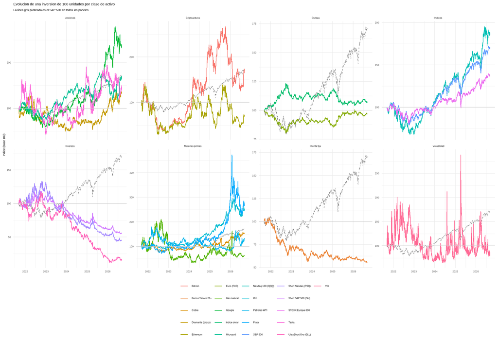

```r
acumulado <- map_dfr(colnames(X), function(nombre) {
  data.frame(
    Date   = fechas,
    Activo = nombre,
    Clase  = unname(clases[nombre]),
    indice = 100 * exp(cumsum(X[ , nombre]))
  )
})

referencia <- acumulado |>
  filter(Activo == "S&P 500") |>
  select(Date, indice)

ggplot(acumulado, aes(x = Date, y = indice, color = Activo)) +
  geom_line(data = referencia, aes(x = Date, y = indice), inherit.aes = FALSE,
            color = "grey55", linetype = "dashed", linewidth = 0.5) +
  geom_line(linewidth = 0.6) +
  geom_hline(yintercept = 100, color = "grey80") +
  facet_wrap(~ Clase, ncol = 4, scales = "free_y") +
  labs(
    title    = "Evolucion de una inversion de 100 unidades por clase de activo",
    subtitle = "La linea gris punteada es el S&P 500 en todos los paneles",
    x        = NULL,
    y        = "Indice (base 100)",
    color    = NULL
  ) +
  theme_minimal() +
  theme(legend.position = "bottom")
```

### Relación diaria con el índice

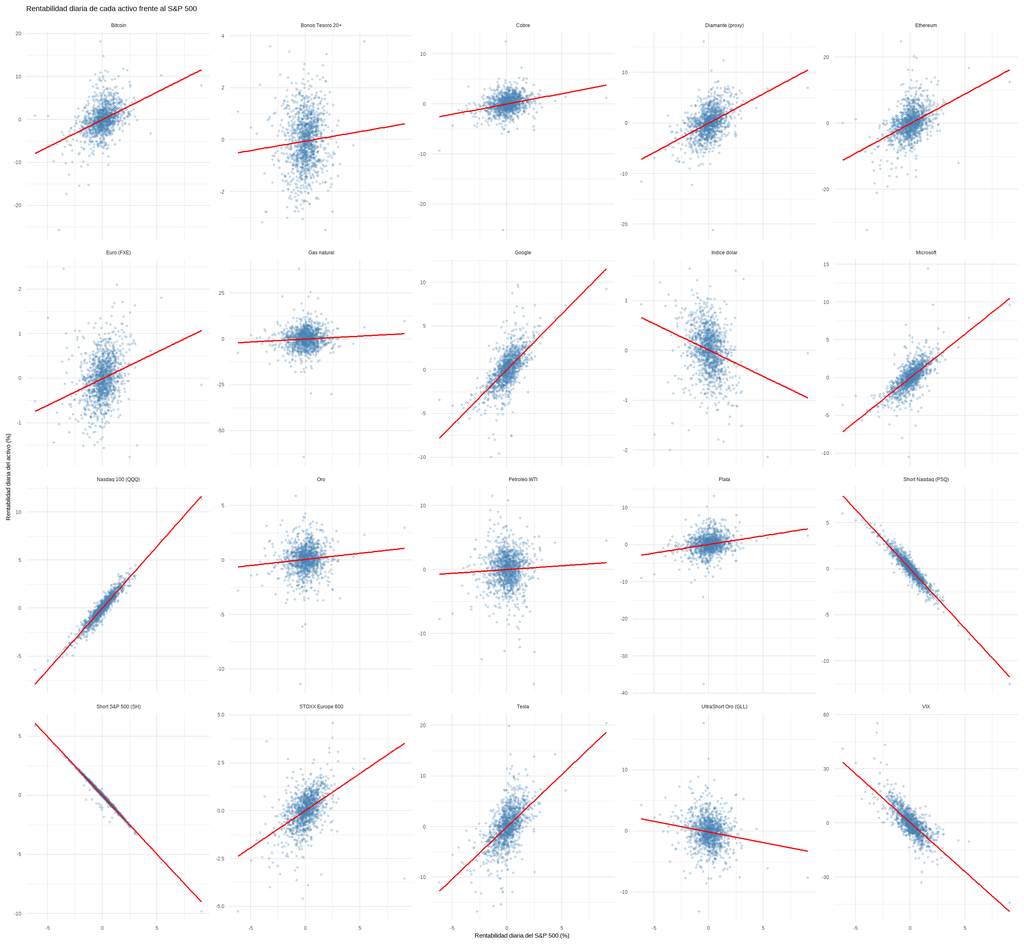

```r
dispersion <- map_dfr(otros, function(nombre) {
  data.frame(
    Activo  = nombre,
    activo  = X[ , nombre] * 100,
    mercado = benchmark * 100
  )
})

ggplot(dispersion, aes(x = mercado, y = activo)) +
  geom_point(alpha = 0.25, size = 0.7, color = "steelblue") +
  geom_smooth(method = "lm", se = FALSE, color = "red", linewidth = 0.7) +
  facet_wrap(~ Activo, scales = "free_y", ncol = 5) +
  labs(
    title = "Rentabilidad diaria de cada activo frente al S&P 500",
    x     = "Rentabilidad diaria del S&P 500 (%)",
    y     = "Rentabilidad diaria del activo (%)"
  ) +
  theme_minimal()
```

### Riesgo frente a rentabilidad

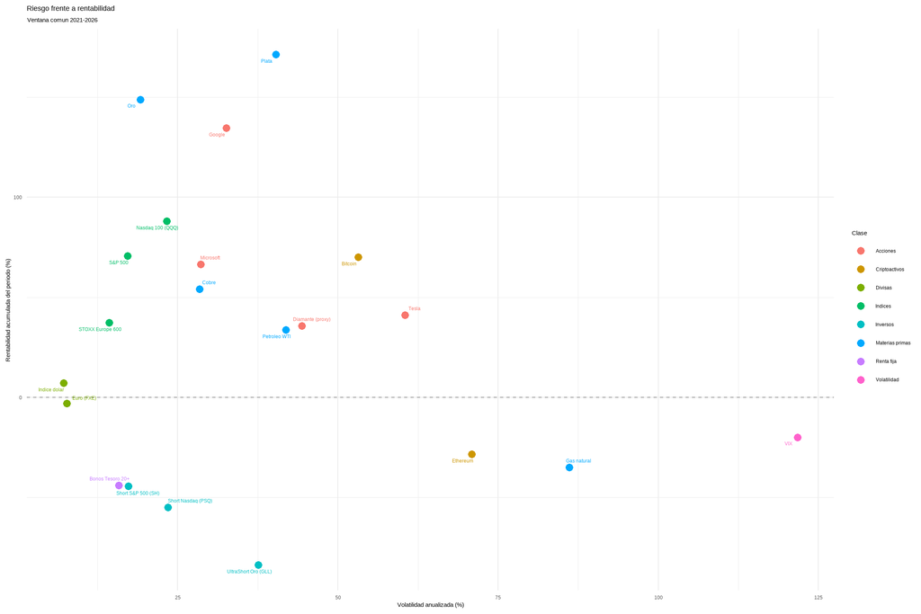

```r
riesgo <- frente_sp |>
  select(Activo, Rend_acum, Vol_anual) |>
  bind_rows(data.frame(
    Activo    = "S&P 500",
    Rend_acum = round((exp(sum(benchmark)) - 1) * 100, 1),
    Vol_anual = round(sd(benchmark) * sqrt(252) * 100, 1)
  )) |>
  mutate(Clase = unname(clases[Activo]))

ggplot(riesgo, aes(x = Vol_anual, y = Rend_acum, color = Clase, label = Activo)) +
  geom_hline(yintercept = 0, linetype = "dashed", color = "grey60") +
  geom_point(size = 3) +
  geom_text_repel(size = 3.2, show.legend = FALSE, max.overlaps = Inf) +
  labs(
    title    = "Riesgo frente a rentabilidad",
    subtitle = "Ventana comun 2021-2026",
    x        = "Volatilidad anualizada (%)",
    y        = "Rentabilidad acumulada del periodo (%)",
    color    = "Clase"
  ) +
  theme_minimal()
```

### Estabilidad de la relación en el tiempo

Los coeficientes anteriores resumen los cinco años en un único número. Para comprobar si esa relación se mantiene estable se calcula la correlación de Spearman móvil con el S&P 500 sobre ventanas de sesenta días de negociación.

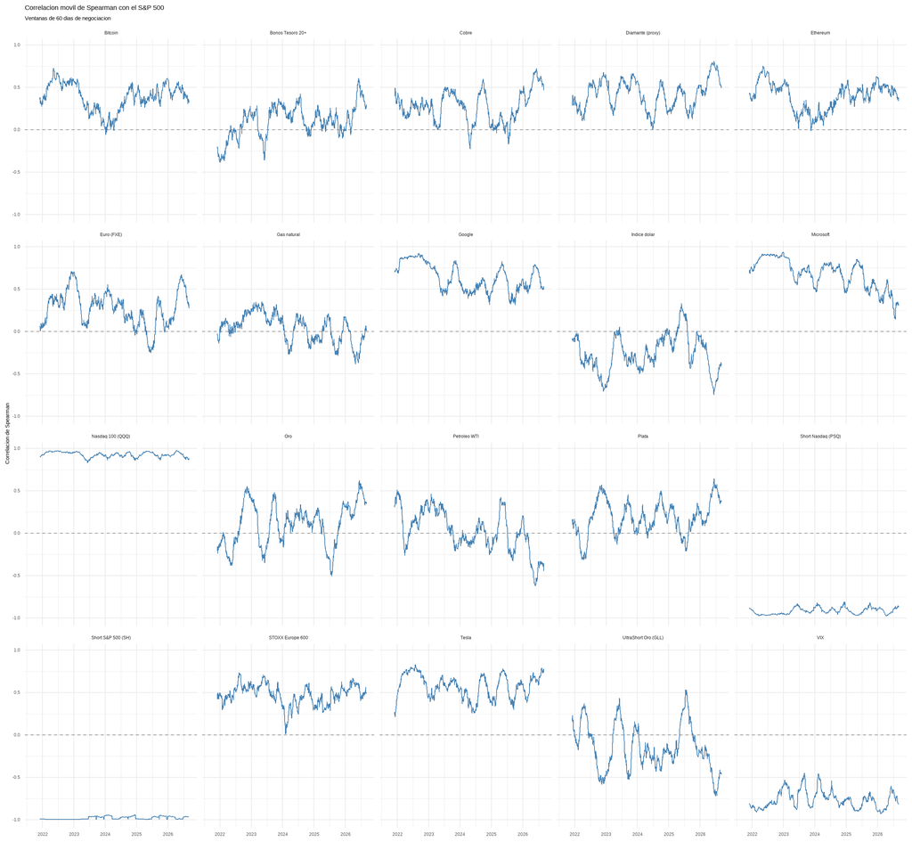

```r
ventana <- 60

movil <- map_dfr(otros, function(nombre) {
  valores <- rep(NA_real_, nrow(X))
  for (i in ventana:nrow(X)) {
    tramo      <- (i - ventana + 1):i
    valores[i] <- cor(X[tramo, nombre], X[tramo, "S&P 500"], method = "spearman")
  }
  data.frame(Date = fechas, Activo = nombre, correlacion = valores)
})

ggplot(movil, aes(x = Date, y = correlacion)) +
  geom_hline(yintercept = 0, linetype = "dashed", color = "grey60") +
  geom_line(color = "steelblue", linewidth = 0.5) +
  facet_wrap(~ Activo, ncol = 5) +
  labs(
    title    = "Correlacion movil de Spearman con el S&P 500",
    subtitle = "Ventanas de 60 dias de negociacion",
    x        = NULL,
    y        = "Correlacion de Spearman"
  ) +
  theme_minimal()
```

### Cobertura frente a diversificación

Los pares con correlación fuertemente negativa invitan a pensar que combinarlos produce una cartera sin riesgo. La tabla evalúa esa idea con carteras de dos activos que se reequilibran cada día a pesos fijos. Las cinco primeras combinan un activo con su espejo; la última combina dos activos con correlación cercana a cero, como referencia. `Peso_1` es la proporción invertida en el primer activo.

```r
combinaciones <- list(
  list("S&P 500",          "Short S&P 500 (SH)",   1/2),
  list("Nasdaq 100 (QQQ)", "Short Nasdaq (PSQ)",   1/2),
  list("Oro",              "UltraShort Oro (GLL)", 1/2),
  list("Oro",              "UltraShort Oro (GLL)", 2/3),
  list("Indice dolar",     "Euro (FXE)",           1/2),
  list("S&P 500",          "Oro",                  1/2)
)

carteras <- map_dfr(combinaciones, function(p) {
  r1      <- exp(X[ , p[[1]]]) - 1
  r2      <- exp(X[ , p[[2]]]) - 1
  w       <- p[[3]]
  cartera <- w * r1 + (1 - w) * r2
  data.frame(
    Activo_1     = p[[1]],
    Activo_2     = p[[2]],
    Peso_1       = round(w, 2),
    Spearman     = round(cor(X[ , p[[1]]], X[ , p[[2]]], method = "spearman"), 3),
    Rend_1       = round((prod(1 + r1) - 1) * 100, 1),
    Rend_2       = round((prod(1 + r2) - 1) * 100, 1),
    Rend_cartera = round((prod(1 + cartera) - 1) * 100, 1),
    Vol_1        = round(sd(r1) * sqrt(252) * 100, 1),
    Vol_2        = round(sd(r2) * sqrt(252) * 100, 1),
    Vol_cartera  = round(sd(cartera) * sqrt(252) * 100, 1)
  )
})

pander(carteras)
```

Table continues below

| Activo_1 | Activo_2 | Peso_1 | Spearman | Rend_1 | Rend_2 |
| --- | --- | --- | --- | --- | --- |
| S&P 500 | Short S&P 500 (SH) | 0.5 | -0.986 | 70.8 | -44.4 |
| Nasdaq 100 (QQQ) | Short Nasdaq (PSQ) | 0.5 | -0.991 | 88.2 | -55 |
| Oro | UltraShort Oro (GLL) | 0.5 | -0.903 | 148.9 | -83.7 |
| Oro | UltraShort Oro (GLL) | 0.67 | -0.903 | 148.9 | -83.7 |
| Indice dolar | Euro (FXE) | 0.5 | -0.939 | 7.2 | -3 |
| S&P 500 | Oro | 0.5 | 0.098 | 70.8 | 148.9 |

| Rend_cartera | Vol_1 | Vol_2 | Vol_cartera |
| --- | --- | --- | --- |
| 4.7 | 17.2 | 17.2 | 1.1 |
| 5 | 23.3 | 23.4 | 1.3 |
| -23 | 19.2 | 37.7 | 10.9 |
| 18.7 | 19.2 | 37.7 | 5.3 |
| 3.3 | 7.2 | 7.7 | 1.4 |
| 113.8 | 17.2 | 19.2 | 13.5 |

### Análisis del desempeño frente al índice

Durante la ventana analizada el S&P 500 acumuló un 70,8 % con una volatilidad anualizada del 17,2 %. Solo cuatro de los veinte activos restantes lo superaron.

**Rendimiento parecido con más riesgo.** Bitcoin acumuló un 70,2 %, prácticamente lo mismo que el índice, pero con una volatilidad del 53,2 %, tres veces mayor. Microsoft acumuló un 66,5 % con un beta de 1,155 y un coeficiente de determinación de 0,484.

**Por debajo del índice.** El cobre (54,2 %), Tesla (41,1 %), el STOXX Europe 600 (37,4 %), Anglo American (35,8 %) y el petróleo (33,8 %) quedaron por debajo del S&P 500. Tesla es el caso más marcado: tiene el beta positivo más alto de la muestra (2,057), una volatilidad del 60,5 % y un intercepto anualizado de −15,61 %, es decir, obtuvo menos de lo que correspondería a su exposición al mercado.

**Divisas.** El índice del dólar (7,2 %) y el euro (−3,0 %) apenas se movieron en términos acumulados, con volatilidades inferiores al 8 %. Fuera del VIX y de los productos inversos, el dólar es el único activo cuya correlación con el S&P 500 es negativa de forma estable: su beta es de −0,106 y su correlación móvil es negativa en el 91 % de las ventanas.

**Pérdidas.** Además del euro, siete activos terminaron con pérdida. Ethereum perdió un 28,3 % con una volatilidad del 70,9 % y un beta de 1,793, muy superior al de bitcoin (1,279). El gas natural perdió un 34,9 % con una volatilidad del 86,1 %. Los bonos del Tesoro a largo plazo perdieron un 44,0 % de su precio, afectados por la subida de tasas de interés iniciada en 2022, con un beta de apenas 0,073: no compensaron las caídas de las acciones. El VIX perdió un 19,9 % en su nivel, con la volatilidad más alta de la muestra (121,7 %), aunque conviene recordar que no es un activo invertible. Los tres productos inversos también perdieron valor: SH un 44,4 %, PSQ un 55,0 % y GLL un 83,7 %. Las dos primeras pérdidas son la contracara de un mercado alcista; la de GLL es la más severa porque combina el apalancamiento doble con un activo de referencia que más que duplicó su precio.

**Cobertura frente a diversificación.** La tabla de carteras resume la lección central del apartado. Combinar el S&P 500 con SH a partes iguales reduce la volatilidad del 17,2 % al 1,1 %, pero también el rendimiento, del 70,8 % al 4,7 % en cinco años: la cartera se comporta prácticamente como efectivo. Lo mismo ocurre con el Nasdaq-100 y PSQ (5,0 % con 1,3 % de volatilidad) y con el dólar y el euro (3,3 % con 1,4 %). Un activo con correlación cercana a −1 no diversifica, cubre: elimina el riesgo junto con el rendimiento. El caso del oro con GLL añade una advertencia práctica. Como GLL es un producto −2x, repartir a partes iguales deja una exposición neta corta al oro y produce una pérdida del 23,0 %; la proporción que neutraliza la exposición es de dos tercios en oro y un tercio en GLL, que da un 18,7 % con 5,3 % de volatilidad. En contraste, combinar el S&P 500 con el oro, cuya correlación es de apenas 0,098, reduce la volatilidad a un 13,5 %, por debajo de la de cualquiera de los dos por separado, y conserva un rendimiento del 113,8 %. Esa es la diferencia entre cubrir y diversificar.

**Estabilidad.** La correlación móvil confirma que solo las relaciones construidas son estables. SH se mantiene entre −1,00 y −0,94 durante todo el periodo, PSQ entre −0,97 y −0,81 y el Nasdaq-100 entre 0,83 y 0,97. El VIX es negativo en todas las ventanas, entre −0,93 y −0,45. El resto de las relaciones cambia de forma apreciable: Microsoft oscila entre 0,94 y 0,15, los bonos del Tesoro entre −0,38 y 0,61, y el petróleo es negativo en el 49 % de las ventanas. Para una estrategia de corto plazo esto implica que una cobertura basada en correlaciones naturales, a diferencia de una basada en productos inversos, puede dejar de funcionar justo cuando más se necesita.

## 10. Simulación de Monte Carlo de carteras

Los apartados anteriores describen lo que ocurrió. Una simulación de Monte Carlo sirve para algo distinto: explorar qué conjunto de resultados es compatible con ese comportamiento. La idea es generar miles de escenarios artificiales a partir de los datos observados y estudiar la distribución de los resultados en lugar de un único camino.

En este apartado se aplica en dos niveles. Primero se simulan carteras, sorteando al azar miles de combinaciones de pesos entre los activos disponibles, para ver qué relaciones entre riesgo y rendimiento eran alcanzables. Después se simulan trayectorias futuras de unas carteras concretas, con tres motores de generación distintos, para comparar qué ocurre cuando se supone normalidad y cuando no se supone nada sobre la distribución.

Antes de simular conviene fijar tres decisiones. El universo se limita a los veinte activos invertibles, excluyendo el VIX, que es un indicador y no un instrumento que se pueda comprar. Los cálculos se hacen sobre rendimientos simples diarios, porque los pesos de una cartera se aplican a ellos y no a los logarítmicos. Y todas las carteras se reequilibran cada día a sus pesos objetivo, que es el supuesto más simple y el que no requiere decidir una regla de reequilibrio.

### 10.1 Universo y carteras de referencia

Se definen siete carteras de referencia. Las cuatro primeras son decisiones de inversión plausibles; la quinta es la cobertura estudiada en el apartado anterior; las dos últimas salen de la propia simulación y se explican más adelante.

```r
invertibles <- setdiff(colnames(X), "VIX")
R           <- exp(X[ , invertibles]) - 1
ndias       <- nrow(R)

metricas <- function(rp) {
  c(Rend = (prod(1 + rp)^(252 / length(rp)) - 1) * 100,
    Vol  = sd(rp) * sqrt(252) * 100)
}

peso <- function(...) {
  v <- c(...)
  w <- setNames(rep(0, ncol(R)), colnames(R))
  w[names(v)] <- v
  w / sum(w)
}
```

```r
set.seed(2026)

S <- 5000
W <- matrix(rexp(S * ncol(R)), nrow = ncol(R))
W <- t(t(W) / colSums(W))
rownames(W) <- colnames(R)

RP <- R %*% W

nube <- data.frame(
  Rend = (apply(1 + RP, 2, prod)^(252 / ndias) - 1) * 100,
  Vol  = apply(RP, 2, sd) * sqrt(252) * 100
) |>
  mutate(Ratio = Rend / Vol)

imin <- which.min(nube$Vol)
imax <- which.max(nube$Ratio)

carteras <- list(
  "Solo S&P 500"    = peso("S&P 500" = 1),
  "Pesos iguales"   = setNames(rep(1 / ncol(R), ncol(R)), colnames(R)),
  "60/40"           = peso("S&P 500" = 0.6, "Bonos Tesoro 20+" = 0.4),
  "Diversificada"   = peso("S&P 500" = 0.35, "Nasdaq 100 (QQQ)" = 0.10, "STOXX Europe 600" = 0.10,
                           "Oro" = 0.20, "Cobre" = 0.05, "Bonos Tesoro 20+" = 0.10,
                           "Bitcoin" = 0.05, "Petroleo WTI" = 0.05),
  "Cubierta 50/50"  = peso("S&P 500" = 0.5, "Short S&P 500 (SH)" = 0.5),
  "Minima varianza" = W[ , imin],
  "Mejor relacion"  = W[ , imax]
)

historico <- map_dfr(names(carteras), function(nombre) {
  rp <- as.vector(R %*% carteras[[nombre]])
  m  <- metricas(rp)
  data.frame(
    Cartera     = nombre,
    Rend_anual  = round(m[1], 2),
    Vol_anual   = round(m[2], 2),
    Acumulado   = round((prod(1 + rp) - 1) * 100, 1),
    Ratio       = round(m[1] / m[2], 3),
    row.names   = NULL
  )
})

pander(historico)
```

| Cartera | Rend_anual | Vol_anual | Acumulado | Ratio |
| --- | --- | --- | --- | --- |
| Solo S&P 500 | 11.67 | 17.24 | 70.8 | 0.677 |
| Pesos iguales | 9.55 | 12.74 | 55.6 | 0.75 |
| 60/40 | 2.47 | 12.54 | 12.5 | 0.197 |
| Diversificada | 12.31 | 12.67 | 75.6 | 0.972 |
| Cubierta 50/50 | 0.95 | 1.14 | 4.7 | 0.828 |
| Minima varianza | 4.49 | 4.34 | 23.7 | 1.033 |
| Mejor relacion | 15.17 | 12.46 | 98.3 | 1.218 |

La columna `Ratio` es el rendimiento anual dividido por la volatilidad anual. No es un coeficiente de Sharpe, porque no descuenta la tasa libre de riesgo, pero ordena las carteras por rendimiento obtenido por unidad de riesgo asumido.

### 10.2 Cinco mil carteras aleatorias

La primera simulación sortea 5.000 vectores de pesos. Cada vector se obtiene generando veinte valores de una distribución exponencial y dividiéndolos por su suma, lo que produce puntos repartidos de manera uniforme sobre el conjunto de carteras posibles sin posiciones cortas. Para cada una se calculan el rendimiento anualizado y la volatilidad que habría tenido en el periodo analizado.

```r
pander(data.frame(
  Carteras        = S,
  Rend_minimo     = round(min(nube$Rend), 1),
  Rend_maximo     = round(max(nube$Rend), 1),
  Vol_minima      = round(min(nube$Vol), 1),
  Vol_maxima      = round(max(nube$Vol), 1),
  Mejor_ratio     = round(max(nube$Ratio), 3)
))
```

| Carteras | Rend_minimo | Rend_maximo | Vol_minima | Vol_maxima | Mejor_ratio |
| --- | --- | --- | --- | --- | --- |
| 5000 | -6.7 | 18.9 | 4.3 | 33.5 | 1.218 |

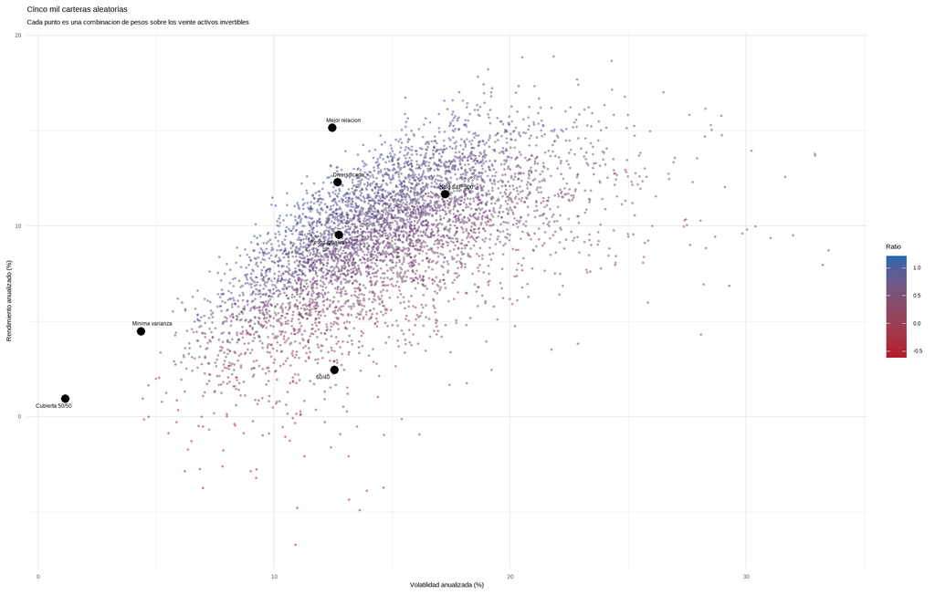

```r
referencias <- historico |>
  mutate(Cartera = factor(Cartera, levels = names(carteras)))

ggplot(nube, aes(x = Vol, y = Rend)) +
  geom_point(aes(color = Ratio), size = 0.6, alpha = 0.45) +
  scale_color_gradient(low = "#b2182b", high = "#2166ac") +
  geom_point(data = referencias, aes(x = Vol_anual, y = Rend_anual),
             inherit.aes = FALSE, size = 3, color = "black") +
  geom_text_repel(data = referencias, aes(x = Vol_anual, y = Rend_anual, label = Cartera),
                  inherit.aes = FALSE, size = 3.2, max.overlaps = Inf) +
  labs(
    title    = "Cinco mil carteras aleatorias",
    subtitle = "Cada punto es una combinacion de pesos sobre los veinte activos invertibles",
    x        = "Volatilidad anualizada (%)",
    y        = "Rendimiento anualizado (%)",
    color    = "Ratio"
  ) +
  theme_minimal()
```

Las dos carteras que la simulación selecciona merecen mirarse por dentro. La tabla muestra los cinco activos con mayor peso en cada una.

```r
mayores <- function(w, etiqueta) {
  orden <- sort(w, decreasing = TRUE)[1:5]
  data.frame(
    Cartera = etiqueta,
    Activo  = names(orden),
    Peso    = round(as.numeric(orden) * 100, 1)
  )
}

pander(bind_rows(
  mayores(carteras[["Minima varianza"]], "Minima varianza"),
  mayores(carteras[["Mejor relacion"]],  "Mejor relacion")
))
```

| Cartera | Activo | Peso |
| --- | --- | --- |
| Minima varianza | Indice dolar | 16 |
| Minima varianza | Short S&P 500 (SH) | 15 |
| Minima varianza | Euro (FXE) | 11.1 |
| Minima varianza | S&P 500 | 9.3 |
| Minima varianza | Google | 7.6 |
| Mejor relacion | Oro | 27.9 |
| Mejor relacion | Indice dolar | 11.7 |
| Mejor relacion | Google | 10.4 |
| Mejor relacion | Gas natural | 6.8 |
| Mejor relacion | Microsoft | 6.5 |

### 10.3 Trayectorias simuladas a un año

La segunda simulación genera el futuro de cada cartera. Se producen 1.000 trayectorias de 252 jornadas con tres motores distintos:

- **Normal.** Cada rendimiento diario se sortea de una distribución normal con la media y la desviación estándar históricas de la cartera. Es el supuesto paramétrico clásico.
- **Bootstrap.** Cada rendimiento diario se extrae al azar, con reemplazo, del conjunto de rendimientos diarios realmente observados. No impone ninguna forma a la distribución, de modo que conserva las colas y la asimetría de los datos, pero rompe el orden temporal.
- **Bloques.** Se extraen tramos consecutivos de veinte jornadas en lugar de días sueltos. Al conservar tramos completos, mantiene parcialmente el agrupamiento de volatilidad que se detectó en el análisis exploratorio.

```r
NSIM <- 1000
B    <- 20

simular <- function(lp, metodo, h) {
  if (metodo == "Normal") {
    matrix(rnorm(NSIM * h, mean(lp), sd(lp)), nrow = h)
  } else if (metodo == "Bootstrap") {
    matrix(sample(lp, NSIM * h, replace = TRUE), nrow = h)
  } else {
    nb  <- ceiling(h / B)
    ini <- matrix(sample(1:(length(lp) - B + 1), NSIM * nb, replace = TRUE), nrow = nb)
    apply(ini, 2, function(col) as.vector(sapply(col, function(i) lp[i:(i + B - 1)]))[1:h])
  }
}

caida_maxima <- function(camino) {
  v <- exp(cumsum(camino))
  max(1 - v / cummax(v)) * 100
}
```

```r
set.seed(2026)

simulacion <- map_dfr(names(carteras), function(nombre) {
  rp <- as.vector(R %*% carteras[[nombre]])
  lp <- log(1 + rp)

  map_dfr(c("Normal", "Bootstrap", "Bloques"), function(metodo) {
    M   <- simular(lp, metodo, 252)
    fin <- 100 * exp(colSums(M))
    dd  <- apply(M, 2, caida_maxima)

    data.frame(
      Cartera       = nombre,
      Metodo        = metodo,
      P5            = round(quantile(fin, 0.05), 1),
      Mediana       = round(median(fin), 1),
      P95           = round(quantile(fin, 0.95), 1),
      Prob_perdida  = round(mean(fin < 100) * 100, 1),
      Caida_mediana = round(median(dd), 1),
      Caida_p95     = round(quantile(dd, 0.95), 1),
      row.names     = NULL
    )
  })
})

pander(simulacion)
```

Table continues below

| Cartera | Metodo | P5 | Mediana | P95 | Prob_perdida |
| --- | --- | --- | --- | --- | --- |
| Solo S&P 500 | Normal | 83.7 | 112.8 | 149.8 | 24.3 |
| Solo S&P 500 | Bootstrap | 84.2 | 111.8 | 147.8 | 26.3 |
| Solo S&P 500 | Bloques | 86.9 | 113.5 | 144.9 | 20.2 |
| Pesos iguales | Normal | 89.5 | 110.9 | 134.9 | 21 |
| Pesos iguales | Bootstrap | 88.7 | 108.8 | 133.6 | 24.2 |
| Pesos iguales | Bloques | 88.2 | 109.9 | 134.4 | 23.4 |
| 60/40 | Normal | 82.7 | 102.9 | 126.7 | 41.5 |
| 60/40 | Bootstrap | 83.4 | 102 | 125.3 | 44.6 |
| 60/40 | Bloques | 82.3 | 103 | 124.3 | 40.2 |
| Diversificada | Normal | 92.6 | 113.2 | 137.9 | 18 |
| Diversificada | Bootstrap | 91.1 | 111.9 | 137.7 | 18.7 |
| Diversificada | Bloques | 91.4 | 113.4 | 137 | 15.4 |
| Cubierta 50/50 | Normal | 99.1 | 101 | 103 | 19.3 |
| Cubierta 50/50 | Bootstrap | 98.9 | 101 | 102.7 | 19 |
| Cubierta 50/50 | Bloques | 99.5 | 101 | 102.4 | 14.3 |
| Minima varianza | Normal | 97.2 | 104.3 | 112.2 | 16.2 |
| Minima varianza | Bootstrap | 97.8 | 104.5 | 111.9 | 14.7 |
| Minima varianza | Bloques | 97.3 | 104.7 | 112 | 14.9 |
| Mejor relacion | Normal | 93.7 | 115.9 | 141.3 | 13.8 |
| Mejor relacion | Bootstrap | 92.5 | 114.7 | 140.6 | 14.6 |
| Mejor relacion | Bloques | 95.6 | 116 | 139.3 | 9.9 |

| Caida_mediana | Caida_p95 |
| --- | --- |
| 13.6 | 25.7 |
| 13.6 | 26.1 |
| 13.3 | 23.7 |
| 9.8 | 19.1 |
| 10.2 | 19.4 |
| 10.3 | 20.4 |
| 11.9 | 22.7 |
| 11.7 | 22.4 |
| 11.9 | 23.2 |
| 9.5 | 18.3 |
| 9.5 | 18 |
| 10.3 | 18.8 |
| 0.9 | 1.9 |
| 0.9 | 2.2 |
| 0.9 | 1.7 |
| 3.3 | 6.7 |
| 3.3 | 6.6 |
| 3.5 | 6.5 |
| 8.9 | 17.2 |
| 9 | 17.1 |
| 9.3 | 16.3 |

Todos los valores están expresados sobre una inversión inicial de 100 unidades. `P5` y `P95` delimitan el intervalo que contiene el 90 % de los escenarios, `Prob_perdida` es el porcentaje de trayectorias que terminan por debajo de 100 y las dos últimas columnas describen la caída máxima sufrida dentro del año.

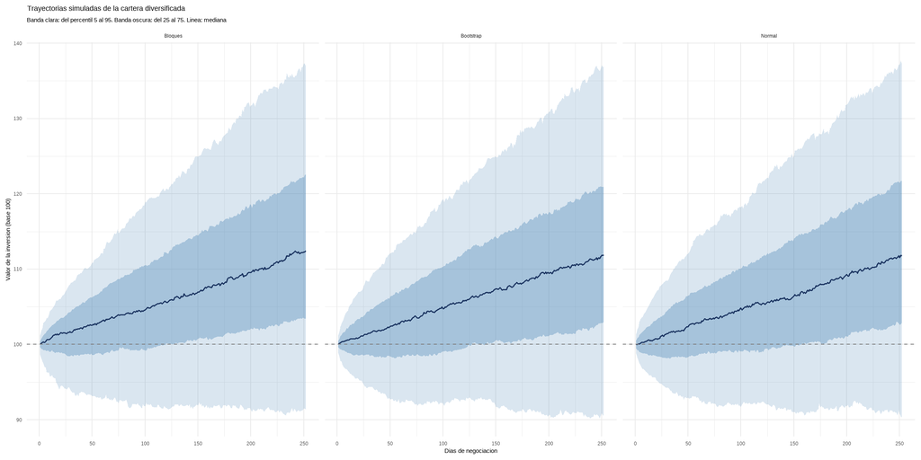

```r
set.seed(7)

lp_div <- log(1 + as.vector(R %*% carteras[["Diversificada"]]))

bandas <- map_dfr(c("Normal", "Bootstrap", "Bloques"), function(metodo) {
  valores <- 100 * exp(apply(simular(lp_div, metodo, 252), 2, cumsum))
  data.frame(
    Dia    = 1:252,
    Metodo = metodo,
    p05    = apply(valores, 1, quantile, 0.05),
    p25    = apply(valores, 1, quantile, 0.25),
    p50    = apply(valores, 1, median),
    p75    = apply(valores, 1, quantile, 0.75),
    p95    = apply(valores, 1, quantile, 0.95)
  )
})

ggplot(bandas, aes(x = Dia)) +
  geom_ribbon(aes(ymin = p05, ymax = p95), fill = "steelblue", alpha = 0.20) +
  geom_ribbon(aes(ymin = p25, ymax = p75), fill = "steelblue", alpha = 0.35) +
  geom_line(aes(y = p50), color = "#1F3864", linewidth = 0.7) +
  geom_hline(yintercept = 100, linetype = "dashed", color = "grey50") +
  facet_wrap(~ Metodo) +
  labs(
    title    = "Trayectorias simuladas de la cartera diversificada",
    subtitle = "Banda clara: del percentil 5 al 95. Banda oscura: del 25 al 75. Linea: mediana",
    x        = "Dias de negociacion",
    y        = "Valor de la inversion (base 100)"
  ) +
  theme_minimal()
```

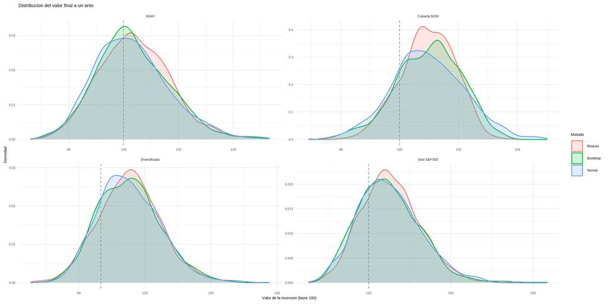

```r
set.seed(7)

finales <- map_dfr(c("Solo S&P 500", "Diversificada", "60/40", "Cubierta 50/50"), function(nombre) {
  lp <- log(1 + as.vector(R %*% carteras[[nombre]]))
  map_dfr(c("Normal", "Bootstrap", "Bloques"), function(metodo) {
    data.frame(
      Cartera = nombre,
      Metodo  = metodo,
      Final   = 100 * exp(colSums(simular(lp, metodo, 252)))
    )
  })
})

ggplot(finales, aes(x = Final, fill = Metodo, color = Metodo)) +
  geom_density(alpha = 0.18, linewidth = 0.6) +
  geom_vline(xintercept = 100, linetype = "dashed", color = "grey50") +
  facet_wrap(~ Cartera, scales = "free", ncol = 2) +
  labs(
    title = "Distribucion del valor final a un anio",
    x     = "Valor de la inversion (base 100)",
    y     = "Densidad"
  ) +
  theme_minimal()
```

### 10.4 ¿Cuánto importa el supuesto de normalidad?

El informe ha insistido en que los rendimientos no son normales. Conviene comprobar qué consecuencias tiene eso dentro de la simulación. La primera comprobación es directa: comparar los cuantiles bajos observados en los rendimientos diarios de cada cartera con los que predice una normal de igual media y desviación.

```r
colas <- map_dfr(c("Solo S&P 500", "Diversificada", "Pesos iguales"), function(nombre) {
  rp <- as.vector(R %*% carteras[[nombre]])
  data.frame(
    Cartera     = nombre,
    P1_empirico = round(quantile(rp, 0.01) * 100, 2),
    P1_normal   = round(qnorm(0.01, mean(rp), sd(rp)) * 100, 2),
    P5_empirico = round(quantile(rp, 0.05) * 100, 2),
    P5_normal   = round(qnorm(0.05, mean(rp), sd(rp)) * 100, 2),
    Peor_dia    = round(min(rp) * 100, 2),
    Curtosis    = round(mean((rp - mean(rp))^4) / sd(rp)^4, 1),
    row.names   = NULL
  )
})

pander(colas)
```

Table continues below

| Cartera | P1_empirico | P1_normal | P5_empirico | P5_normal | Peor_dia |
| --- | --- | --- | --- | --- | --- |
| Solo S&P 500 | -2.99 | -2.48 | -1.65 | -1.74 | -5.97 |
| Diversificada | -2.12 | -1.81 | -1.23 | -1.26 | -4.44 |
| Pesos iguales | -2.12 | -1.83 | -1.25 | -1.28 | -4.06 |

| Curtosis |
| --- |
| 9.9 |
| 7.3 |
| 5.3 |

La segunda comprobación repite la simulación con un horizonte de diez jornadas en lugar de un año.

```r
set.seed(2026)

corto <- map_dfr(c("Solo S&P 500", "Diversificada", "Mejor relacion"), function(nombre) {
  lp <- log(1 + as.vector(R %*% carteras[[nombre]]))
  map_dfr(c("Normal", "Bootstrap", "Bloques"), function(metodo) {
    fin <- 100 * exp(colSums(simular(lp, metodo, 10)))
    data.frame(
      Cartera      = nombre,
      Metodo       = metodo,
      P1           = round(quantile(fin, 0.01), 1),
      P5           = round(quantile(fin, 0.05), 1),
      Mediana      = round(median(fin), 1),
      P99          = round(quantile(fin, 0.99), 1),
      Prob_perdida = round(mean(fin < 100) * 100, 1),
      row.names    = NULL
    )
  })
})

pander(corto)
```

| Cartera | Metodo | P1 | P5 | Mediana | P99 | Prob_perdida |
| --- | --- | --- | --- | --- | --- | --- |
| Solo S&P 500 | Normal | 92.9 | 94.7 | 100.6 | 109 | 43.8 |
| Solo S&P 500 | Bootstrap | 91.8 | 94.9 | 100.5 | 108.9 | 44.7 |
| Solo S&P 500 | Bloques | 91.6 | 94.3 | 100.6 | 108.1 | 41.8 |
| Diversificada | Normal | 94.5 | 96.2 | 100.5 | 106.5 | 41.3 |
| Diversificada | Bootstrap | 94.4 | 96.5 | 100.5 | 106.8 | 42.3 |
| Diversificada | Bloques | 93.3 | 96.5 | 100.8 | 106.1 | 36.5 |
| Mejor relacion | Normal | 94.8 | 96.4 | 100.6 | 106.5 | 40 |
| Mejor relacion | Bootstrap | 95 | 96.4 | 100.7 | 106.3 | 41 |
| Mejor relacion | Bloques | 94.3 | 96.4 | 100.7 | 106.3 | 38.3 |

### 10.5 Análisis de la simulación

**Las carteras aleatorias delimitan lo que era alcanzable.** Las 5.000 combinaciones cubren rendimientos anualizados entre −6,7 % y 18,9 % y volatilidades entre 4,3 % y 33,5 %. La nube tiene la forma habitual: el rendimiento aumenta con el riesgo, pero con una dispersión enorme, de manera que para casi cualquier nivel de volatilidad existían carteras buenas y carteras malas. La relación entre rendimiento y volatilidad llega como máximo a 1,218.

**La diversificación hecha a mano funcionó mejor que el índice.** La cartera diversificada obtuvo un 12,31 % anual con un 12,67 % de volatilidad, frente al 11,67 % y el 17,24 % del S&P 500. Su relación entre rendimiento y riesgo es de 0,972 contra 0,677 del índice, es decir, más rendimiento con casi un tercio menos de volatilidad. La cartera de pesos iguales, que no requiere ninguna decisión, alcanza 0,750 y también supera al índice en esa medida.

**La cartera clásica 60/40 fue la peor del grupo.** Obtuvo un 2,47 % anual con un 12,54 % de volatilidad y una relación de 0,197. La causa está documentada en el apartado 9: los bonos del Tesoro a largo plazo perdieron un 44 % de su precio en el periodo y su correlación con las acciones fue de 0,093, de modo que aportaron riesgo sin aportar ni rendimiento ni protección. Es un recordatorio de que una regla de cartera reputada puede fallar durante cinco años seguidos si cambia el régimen de tasas de interés.

**A un año, los tres motores de simulación dicen casi lo mismo.** Para la cartera diversificada, el percentil 5 queda entre 91,1 y 92,6 según el método, la mediana entre 111,9 y 113,4 y la probabilidad de terminar con pérdida entre el 15,4 % y el 18,7 %. Para el S&P 500 las diferencias son algo mayores, con probabilidades de pérdida entre el 20,2 % y el 26,3 %, pero siguen siendo pequeñas frente a la incertidumbre total.

**La diferencia sí aparece en el horizonte corto.** En los rendimientos diarios, la normal subestima claramente la cola izquierda: el percentil 1 observado del S&P 500 es de −2,99 %, mientras que la normal predice −2,48 %, y el peor día del periodo fue de −5,97 %, un valor que una normal considera prácticamente imposible. La curtosis de 9,9 confirma el exceso de valores extremos. A diez jornadas esa diferencia todavía se nota: el percentil 1 del valor final es 92,9 con el motor normal y 91,8 y 91,6 con el bootstrap y con los bloques. A 252 jornadas la diferencia se desvanece, porque sumar muchos rendimientos independientes acerca el resultado a una normal por el teorema central del límite. La conclusión práctica es precisa: para medir el riesgo de un año el supuesto de normalidad no cambia mucho las cifras, pero para gestionar el riesgo diario o semanal de una estrategia de corto plazo sí lo hace, y ahí conviene el enfoque no paramétrico.

**La cobertura vuelve a mostrar su costo.** La cartera cubierta al 50 % termina entre 99 y 103 en el 90 % de los escenarios, con una caída máxima mediana del 0,9 %. Casi no puede perder, pero tampoco puede ganar. Es la versión simulada de lo que el apartado 9 mostró con datos reales.

**Los límites del ejercicio deben quedar claros.** Los tres motores suponen que el futuro se parece al pasado reciente: el normal toma su media y su desviación, y los dos no paramétricos reutilizan literalmente los rendimientos observados. Ninguno incorpora cambios de régimen, ni la inestabilidad de las correlaciones documentada en el apartado 9, ni costos de transacción, ni el efecto de reequilibrar a diario una cartera real. El motor de bloques recupera parte de la dependencia temporal, pero solo dentro de tramos de veinte días. Por eso los resultados deben leerse como un rango de escenarios compatible con el pasado, y no como una previsión.

## 11. Posibles pasos siguientes

El informe cierra la etapa descriptiva del proyecto. Los pasos que siguen se agrupan en seis frentes.

**Datos.** Sustituir el precio de cierre por el cierre ajustado para incorporar dividendos e intereses, lo que corregiría la subestimación del rendimiento de Microsoft, de Anglo American y sobre todo del fondo de bonos. Revisar los saltos por cambio de contrato en las series continuas de futuros, especialmente los días extremos del gas natural y de la plata. Ampliar la ventana más allá de cinco años para cubrir más de un régimen de mercado, aceptando que no todos los activos tienen histórico suficiente.

**Dependencia.** La correlación de distancias detectó una posible dependencia no monótona entre el petróleo y la renta variable que la correlación de rangos no ve. El paso natural es modelar la estructura de dependencia con cópulas, que separan las distribuciones individuales de la forma en que se relacionan, y contrastar la dependencia en las colas, es decir, si los activos caen juntos con más frecuencia de la que sugiere su correlación media. Una alternativa complementaria son los modelos de correlación condicional variable en el tiempo, coherentes con la inestabilidad que mostró el análisis de ventanas móviles.

**Series de tiempo.** Ajustar modelos de la familia ARIMA sobre los rendimientos y modelos de volatilidad condicional para la varianza, justificados por el agrupamiento de volatilidad observado. Contrastar formalmente la estacionariedad de las series transformadas y evaluar modelos de cambio de régimen, que permitirían representar los tramos en que las correlaciones cambian de signo.

**Optimización de carteras.** Sustituir el sorteo aleatorio de pesos por una optimización explícita: mínima varianza, máxima relación entre rendimiento y riesgo, y paridad de riesgo. Estimar la matriz de covarianzas con métodos robustos o de contracción, porque con veinte activos y mil observaciones la estimación directa es inestable. Y, sobre todo, validar fuera de muestra: elegir los pesos en un periodo, aplicarlos en el siguiente, reequilibrar con una regla fija e incluir costos de transacción. La cartera de pesos iguales debe usarse como referencia exigente, ya que en este periodo superó al índice sin necesidad de estimar nada.

**Simulación.** Reemplazar el bootstrap de bloques de longitud fija por un bootstrap estacionario, con longitud aleatoria, que evita artefactos en los extremos de cada tramo. Simular la cartera completa a partir de las marginales empíricas y una cópula ajustada, en lugar de simular directamente el rendimiento agregado, lo que permitiría que la dependencia entre activos cambie con el escenario. Añadir escenarios de estrés basados en episodios históricos concretos y medir el resultado con déficit esperado además de valor en riesgo.

**Evaluación y decisión.** Construir reglas de decisión a partir de los pronósticos, evaluarlas con validación progresiva en el tiempo y comparar su desempeño con pruebas no paramétricas, que es el terreno natural para contrastar estrategias cuyos rendimientos no son normales. Antes de cualquier aplicación con dinero real, el proyecto debería pasar por una fase de simulación en papel, con datos en tiempo real y costos incluidos.

**Riesgos que conviene tener presentes.** El principal es el sobreajuste: cuantas más combinaciones se prueben sobre el mismo periodo, más probable es encontrar una que funcione por azar, como ilustran las dos carteras seleccionadas por la simulación. El segundo es la dependencia de una única ventana temporal. El tercero, de orden práctico, es que todo el análisis se apoya en una sola fuente de datos gratuita que, como se documentó en el apartado 6, revisa sus series sin previo aviso. Este trabajo es académico y no constituye una recomendación de inversión.